# Cross-Selling: Use Case

Fernando Millan Villalobos

February 2020

# 1 Notes

This report was generated on 2020-06-09 18:17:09. R version: 4.0.0 on x86_64-w64-mingw32. For this report, CRAN packages as of 2020-06-01 were used.

…

## 1.1 R-Script & data

The preprocessing and analysis of the data was conducted in the [R project for statistical computing](https://www.r-project.org/). The RMarkdown script used to generate this document and all the resulting data can be downloaded [under this link](http://fernandomillanvillalobos.github.io/fs20c2_cross-selling-in-banking/). Through executing `main.Rmd`, the herein described process can be reproduced and this document can be generated. In the course of this, data from the folder `input` will be processed and results will be written to `output`. The html on-line version of the analysis can be accessed through this [link](https://fernandomillanvillalobos.github.io/fs20c2_cross-selling-in-banking/).

## 1.2 GitHub

The code for the herein described process can also be freely downloaded from https://github.com/fernandomillanvillalobos/fs20c2_cross-selling-in-banking.

## 1.3 License

…

## 1.4 Data description of output files

#### 1.4.0.1 `sample_client_dataset.Rdata`

| account_id | client_id | gender | age |
| --- | --- | --- | --- |
| 65 | 76 | female | 31 |

# 2 Set up

```
## [1] "package package:rstudioapi detached"
```

```
## [1] "package package:knitr detached"
```

## 2.1 Define packages

```r
# from https://mran.revolutionanalytics.com/web/packages/\
# checkpoint/vignettes/using-checkpoint-with-knitr.html
# if you don't need a package, remove it from here (commenting not sufficient)
# tidyverse: see https://blog.rstudio.org/2016/09/15/tidyverse-1-0-0/
cat("
library(rstudioapi)
library(tidyverse) # ggplot2, dplyr, tidyr, readr, purrr, tibble, magrittr, readxl
library(scales) # scales for ggplot2
library(jsonlite) # json
library(lintr) # code linting
library(sf) # spatial data handling
library(rmarkdown)
library(RPostgreSQL) # sql database
library(DBI) # database
library(treemap) # treemap plots
library(hrbrthemes) # plots
library(ggridges) # density plots
library(cowplot) # theme
library(extrafont)", # fonts
file = "manifest.R")
```

## 2.2 Install packages

```r
# if checkpoint is not yet installed, install it (for people using this
# system for the first time)
if (!require(checkpoint)) {
  if (!require(devtools)) {
    install.packages("devtools", repos = "http://cran.us.r-project.org")
    require(devtools)
  }
  devtools::install_github("RevolutionAnalytics/checkpoint",
                           ref = "v0.4.9", # could be adapted later,
                           # as of now (beginning of July 2017
                           # this is the current release on CRAN)
                           repos = "http://cran.us.r-project.org")
  require(checkpoint)
}
# nolint start
if (!dir.exists("~/.checkpoint")) {
  dir.create("~/.checkpoint")
}
# nolint end
# install packages for the specified CRAN snapshot date
checkpoint(snapshotDate = package_date,
           project = path_to_wd,
           verbose = T,
           scanForPackages = T,
           use.knitr = F,
           R.version = r_version)
rm(package_date)
```

## 2.3 Load packages

```r
source("manifest.R")
unlink("manifest.R")
```

## 2.4 Load additional scripts

```r
# if you want to outsource logic to other script files, see README for
# further information
# Load all visualizations functions as separate scripts
knitr::read_chunk("scripts/dviz.supp.R")
source("scripts/dviz.supp.R")
knitr::read_chunk("scripts/themes.R")
source("scripts/themes.R")
knitr::read_chunk("scripts/plot_grid.R")
source("scripts/plot_grid.R")
knitr::read_chunk("scripts/align_legend.R")
source("scripts/align_legend.R")
knitr::read_chunk("scripts/label_log10.R")
source("scripts/label_log10.R")
knitr::read_chunk("scripts/colors.R")
source("scripts/colors.R")
```

## 2.5 Connection

```r
DB_HOST='server2053.cs.technik.fhnw.ch' # or 86.119.36.94 depending on the network
DB_PORT = 5432
DB_DBNAME = 'bank_db' # or 'warenkorb_db'
DB_USERNAME = 'db_user'
DB_PASSWORD = 'db_user_pw'
# load the PostgreSQL driver
drv <- dbDriver("PostgreSQL")
# connect to the database
con <- dbConnect(drv, dbname = DB_DBNAME,
                 host = DB_HOST, port = DB_PORT,
                 user = DB_USERNAME, password = DB_PASSWORD)
```

## 2.6 Customization

### 2.6.1 Theme

```r
theme_set(theme_cowplot(font_size = 11))
```

# 3 Data Importing and Pre-Processing

## Relation disposition

Import the relation disposition (disp), within each record relates together a client with an account.

```sql
SELECT *
FROM
  disp
```

Transform the imported dataframe as tibble to work easier with dplyr

```r
disp <- as_tibble(disp)
disp
```

| disp_id | client_id | account_id | type |
| --- | --- | --- | --- |
| 1 | 1 | 1 | OWNER |
| 2 | 2 | 2 | OWNER |
| 3 | 3 | 2 | DISPONENT |
| 4 | 4 | 3 | OWNER |
| 5 | 5 | 3 | DISPONENT |
| 6 | 6 | 4 | OWNER |
| 7 | 7 | 5 | OWNER |
| 8 | 8 | 6 | OWNER |
| 9 | 9 | 7 | OWNER |
| 10 | 10 | 8 | OWNER |
| 11 | 11 | 8 | DISPONENT |
| 12 | 12 | 9 | OWNER |
| 13 | 13 | 10 | OWNER |
| 14 | 14 | 11 | OWNER |
| 15 | 15 | 12 | OWNER |
| 16 | 16 | 12 | DISPONENT |
| 17 | 17 | 13 | OWNER |
| 18 | 18 | 13 | DISPONENT |
| 19 | 19 | 14 | OWNER |
| 20 | 20 | 15 | OWNER |
| 21 | 21 | 16 | OWNER |
| 22 | 22 | 17 | OWNER |
| 23 | 23 | 17 | DISPONENT |
| 24 | 24 | 18 | OWNER |
| 25 | 25 | 19 | OWNER |
| 26 | 26 | 20 | OWNER |
| 27 | 27 | 21 | OWNER |
| 28 | 28 | 22 | OWNER |
| 29 | 29 | 23 | OWNER |
| 30 | 30 | 24 | OWNER |

[output cut: 5339 more lines]

Check if the table was correct imported (every object and every variable).

```r
nrow(disp)
```

```
## [1] 5369
```

```r
ncol(disp)
```

```
## [1] 4
```

Run str() to identify variable types and identify problems.

```r
str(disp)
```

```
## tibble [5,369 x 4] (S3: tbl_df/tbl/data.frame)
##  $ disp_id   : int [1:5369] 1 2 3 4 5 6 7 8 9 10 ...
##  $ client_id : int [1:5369] 1 2 3 4 5 6 7 8 9 10 ...
##  $ account_id: int [1:5369] 1 2 2 3 3 4 5 6 7 8 ...
##  $ type      : chr [1:5369] "OWNER" "OWNER" "DISPONENT" "OWNER" ...
```

Check if there are NA´s.

```r
sum(is.na(disp))
```

```
## [1] 0
```

Look at the top and the bottom of our data to let us know if the data were read properly, properly formatted and that everything is there. Looking at the tail is particulary useful because often there will be some problem like weird formatting or some extra comment lines reading the end of a data set.

```r
head(disp)
```

| disp_id | client_id | account_id | type |
| --- | --- | --- | --- |
| 1 | 1 | 1 | OWNER |
| 2 | 2 | 2 | OWNER |
| 3 | 3 | 2 | DISPONENT |
| 4 | 4 | 3 | OWNER |
| 5 | 5 | 3 | DISPONENT |
| 6 | 6 | 4 | OWNER |

```r
tail(disp)
```

| disp_id | client_id | account_id | type |
| --- | --- | --- | --- |
| 13623 | 13931 | 11333 | OWNER |
| 13647 | 13955 | 11349 | OWNER |
| 13648 | 13956 | 11349 | DISPONENT |
| 13660 | 13968 | 11359 | OWNER |
| 13663 | 13971 | 11362 | OWNER |
| 13690 | 13998 | 11382 | OWNER |

Make a new cleansed data set from the original to work with.

```r
dispOK <- disp
```

The table disp connects account and client (i.e. a many-to-many relation between client and account through the disp table). Look at the unique values for every variable (column).

```sql
SELECT
   COUNT(*) as total_count,
   COUNT(DISTINCT client_id) as client_count,
   COUNT(DISTINCT account_id) as account_count
FROM
   disp
```

1 records

| total_count | client_count | account_count |
| --- | --- | --- |
| 5369 | 5369 | 4500 |

After running the code we can see that there is the same number of client_id and dispOK_id (5369) but not for account_id (4500). Based on this we can assume that each client has exactly one account even thought the datamodel would allow for clients having from 0..m accounts (it is a many-to-many relation between client and account through the disp table). At the same time we know that some accounts are owned by more than one client.

The most interesting characteristic for a categorical variable is the frequency of his values. We focus our attention in the account type variable (type). We want to know how many accounts clients own.

```sql
SELECT
   STRING_AGG(client_id::text, '+') as clients,
   STRING_AGG(type, '+') as types,
   account_id,
   COUNT(account_id) as count
FROM
   disp
GROUP BY
   account_id
ORDER BY
       count DESC,
   account_id
   LIMIT 5
```

5 records

| clients | types | account_id | count |
| --- | --- | --- | --- |
| 2+3 | OWNER+DISPONENT | 2 | 2 |
| 4+5 | OWNER+DISPONENT | 3 | 2 |
| 10+11 | OWNER+DISPONENT | 8 | 2 |
| 15+16 | OWNER+DISPONENT | 12 | 2 |
| 17+18 | OWNER+DISPONENT | 13 | 2 |

Lets see how many accounts have 2 and how many have 1 clients.

```sql
SELECT
   STRING_AGG(DISTINCT types, '+') as types,
   count,
   COUNT(count) as counted_counts
FROM
   (
      SELECT
         STRING_AGG(type, '+') as types,
         account_id,
         COUNT(account_id) as count
      FROM
         disp
      GROUP BY
         account_id
      ORDER BY
         count DESC
   )
   as counts_table
GROUP BY
   count
```

```r
pct_accounts <-  accounts_table %>%
  mutate(freq = counted_counts / sum(counted_counts), pct = round((freq*100), 0))
pct_accounts
```

| types | count | counted_counts | freq | pct |
| --- | --- | --- | --- | --- |
| OWNER | 1 | 3631 | 0.8068889 | 81 |
| OWNER+DISPONENT | 2 | 869 | 0.1931111 | 19 |

Together we have exactly 869 + 3631 = 4500 distinct accounts in disp (which is equal to the number of accounts). From the total number of accounts that we have, 81% of them are OWNERS and the remained 19% are OWNER+DISPONENT.

```sql
SELECT
   STRING_AGG(DISTINCT types, '+') as types,
   count,
   SUM(count) as summed_counts
FROM
   (
      SELECT
         STRING_AGG(type, '+') as types,
         account_id,
         COUNT(account_id) as count
      FROM
         disp
      GROUP BY
         account_id
      ORDER BY
         count DESC
   )
   as counts_table
GROUP BY
   count
```

```r
pct_clients <-  clients_table %>%
  mutate(freq = summed_counts / sum(summed_counts), pct = round((freq*100), 0))
pct_clients
```

| types | count | summed_counts | freq | pct |
| --- | --- | --- | --- | --- |
| OWNER | 1 | 3631 | 0.6762898 | 68 |
| OWNER+DISPONENT | 2 | 1738 | 0.3237102 | 32 |

Together we reference exactly 1738 + 3631 = 5369 accounts through disp (this also counts multi occurences of the same account - which is equal to the number of clients). We found that 68% of our clients are OWNERS and 32% OWNER+DISPONENT.

## Relation demographie

Import the relation district (district), each record describes demographic characteristics of a district. Because it is difficult to identify the variables by the original names, we are going to rename the columns with new ones that describe which information the variables hold.

```sql
SELECT
  a1 as district_code,
  a2 as district_name,
  a3 as region,
  a4 as population,
  a5 as pop_499_or_less,
  a6 as pop_500_1999,
  a7 as pop_2000_9999,
  a8 as pop_10000_or_more,
  a9 as city_number,
  a10 as ratio_urban_population,
  a11 as average_salary,
  a12 as unemployment_1995,
  a13 as unemployment_1996,
  a14 as enterpreneurs_per_100,
  a15 as crimes_1995,
  a16 as crimes_1996
FROM district
```

```r
head(district)
```

| district_code | district_name | region | population | pop_499_or_less | pop_500_1999 | pop_2000_9999 | pop_10000_or_more | city_number | ratio_urban_population | average_salary | unemployment_1995 | unemployment_1996 | enterpreneurs_per_100 | crimes_1995 | crimes_1996 |
| --- | --- | --- | --- | --- | --- | --- | --- | --- | --- | --- | --- | --- | --- | --- | --- |
| 1 | Hl.m. Praha | Prague | 1204953 | 0 | 0 | 0 | 1 | 1 | 100.0 | 12541 | 0.29 | 0.43 | 167 | 85677 | 99107 |
| 2 | Benesov | central Bohemia | 88884 | 80 | 26 | 6 | 2 | 5 | 46.7 | 8507 | 1.67 | 1.85 | 132 | 2159 | 2674 |
| 3 | Beroun | central Bohemia | 75232 | 55 | 26 | 4 | 1 | 5 | 41.7 | 8980 | 1.95 | 2.21 | 111 | 2824 | 2813 |
| 4 | Kladno | central Bohemia | 149893 | 63 | 29 | 6 | 2 | 6 | 67.4 | 9753 | 4.64 | 5.05 | 109 | 5244 | 5892 |
| 5 | Kolin | central Bohemia | 95616 | 65 | 30 | 4 | 1 | 6 | 51.4 | 9307 | 3.85 | 4.43 | 118 | 2616 | 3040 |
| 6 | Kutna Hora | central Bohemia | 77963 | 60 | 23 | 4 | 2 | 4 | 51.5 | 8546 | 2.95 | 4.02 | 126 | 2640 | 3120 |

Transform the imported dataframe as tibble to work easier with dplyr.

```r
district <- as_tibble(district)
```

Check if the table was correct imported (every object and every variable)

```r
nrow(district)
```

```
## [1] 77
```

```r
ncol(district)
```

```
## [1] 16
```

Run str() to identify variable types and identify problems.

```r
str(district)
```

```
## tibble [77 x 16] (S3: tbl_df/tbl/data.frame)
##  $ district_code         : int [1:77] 1 2 3 4 5 6 7 8 9 10 ...
##  $ district_name         : chr [1:77] "Hl.m. Praha" "Benesov" "Beroun" "Kladno" ...
##  $ region                : chr [1:77] "Prague" "central Bohemia" "central Bohemia" "central Bohemia" ...
##  $ population            : int [1:77] 1204953 88884 75232 149893 95616 77963 94725 112065 81344 92084 ...
##  $ pop_499_or_less       : int [1:77] 0 80 55 63 65 60 38 95 61 55 ...
##  $ pop_500_1999          : int [1:77] 0 26 26 29 30 23 28 19 23 29 ...
##  $ pop_2000_9999         : int [1:77] 0 6 4 6 4 4 1 7 4 4 ...
##  $ pop_10000_or_more     : int [1:77] 1 2 1 2 1 2 3 1 2 3 ...
##  $ city_number           : int [1:77] 1 5 5 6 6 4 6 8 6 5 ...
##  $ ratio_urban_population: num [1:77] 100 46.7 41.7 67.4 51.4 51.5 63.4 69.4 55.3 46.7 ...
##  $ average_salary        : int [1:77] 12541 8507 8980 9753 9307 8546 9920 11277 8899 10124 ...
##  $ unemployment_1995     : num [1:77] 0.29 1.67 1.95 4.64 3.85 2.95 2.26 1.25 3.39 0.56 ...
##  $ unemployment_1996     : num [1:77] 0.43 1.85 2.21 5.05 4.43 4.02 2.87 1.44 3.97 0.54 ...
##  $ enterpreneurs_per_100 : int [1:77] 167 132 111 109 118 126 130 127 149 141 ...
##  $ crimes_1995           : num [1:77] 85677 2159 2824 5244 2616 ...
##  $ crimes_1996           : int [1:77] 99107 2674 2813 5892 3040 3120 4846 4987 2487 4316 ...
```

Transform categorical variables (district_name and region) as Factor.

```r
district$district_name <- as.factor(district$district_name)
district$region <- as.factor(district$region)
```

Add a new column with the abbreviation codes (ISO 3166-2) for each region for visualization purpose.

```r
iso <- district$region %>%
  fct_recode(
              "CST" = "central Bohemia",
              "CVC" = "east Bohemia",
              "CSC" = "north Bohemia",
              "CSM" = "north Moravia",
              "PRG" = "Prague",
              "CJC" = "south Bohemia",
              "CJM" = "south Moravia",
              "CZC" = "west Bohemia"
            )
district <- add_column(district, iso)
```

Using the built-in function summary allows us to check if there are NA´s, locate them and get basic statistical information about the data set.

```r
sum(is.na(district))
```

```
## [1] 2
```

```r
summary(district)
```

```
##  district_code       district_name             region     population
##  Min.   : 1    Benesov      : 1    south Moravia  :14   Min.   :  42821
##  1st Qu.:20    Beroun       : 1    central Bohemia:12   1st Qu.:  85852
##  Median :39    Blansko      : 1    east Bohemia   :11   Median : 108871
##  Mean   :39    Breclav      : 1    north Moravia  :11   Mean   : 133885
##  3rd Qu.:58    Brno - mesto : 1    north Bohemia  :10   3rd Qu.: 139012
##  Max.   :77    Brno - venkov: 1    west Bohemia   :10   Max.   :1204953
##                (Other)      :71    (Other)        : 9
##  pop_499_or_less   pop_500_1999   pop_2000_9999    pop_10000_or_more
##  Min.   :  0.00   Min.   : 0.00   Min.   : 0.000   Min.   :0.000
##  1st Qu.: 22.00   1st Qu.:16.00   1st Qu.: 4.000   1st Qu.:1.000
##  Median : 49.00   Median :25.00   Median : 6.000   Median :2.000
##  Mean   : 48.62   Mean   :24.32   Mean   : 6.273   Mean   :1.727
##  3rd Qu.: 71.00   3rd Qu.:32.00   3rd Qu.: 8.000   3rd Qu.:2.000
##  Max.   :151.00   Max.   :70.00   Max.   :20.000   Max.   :5.000
##
##   city_number    ratio_urban_population average_salary  unemployment_1995
##  Min.   : 1.00   Min.   : 33.90         Min.   : 8110   Min.   :0.290
##  1st Qu.: 5.00   1st Qu.: 51.90         1st Qu.: 8512   1st Qu.:1.788
##  Median : 6.00   Median : 59.80         Median : 8814   Median :2.825
##  Mean   : 6.26   Mean   : 63.04         Mean   : 9032   Mean   :3.119
##  3rd Qu.: 8.00   3rd Qu.: 73.50         3rd Qu.: 9317   3rd Qu.:3.890
##  Max.   :11.00   Max.   :100.00         Max.   :12541   Max.   :7.340
##                                                         NA's   :1
##  unemployment_1996 enterpreneurs_per_100  crimes_1995     crimes_1996
##  Min.   :0.430     Min.   : 81.0         Min.   :  818   Min.   :  888
##  1st Qu.:2.310     1st Qu.:105.0         1st Qu.: 2030   1st Qu.: 2122
##  Median :3.600     Median :113.0         Median : 2932   Median : 3040
##  Mean   :3.787     Mean   :116.1         Mean   : 4850   Mean   : 5031
##  3rd Qu.:4.790     3rd Qu.:126.0         3rd Qu.: 4526   3rd Qu.: 4595
##  Max.   :9.400     Max.   :167.0         Max.   :85677   Max.   :99107
##                                          NA's   :1
##       iso
##  CJM    :14
##  CST    :12
##  CVC    :11
##  CSM    :11
##  CSC    :10
##  CZC    :10
##  (Other): 9
```

From summary we found that there are two variables (unemployment_1995 and crimes_1995) that have a couple of missing values. We are goint to get rid of them to avoid problems when plotting.

```r
district <- drop_na(district)
summary(district)
```

```
##  district_code         district_name             region     population
##  Min.   : 1.00   Benesov      : 1    south Moravia  :14   Min.   :  45714
##  1st Qu.:19.75   Beroun       : 1    central Bohemia:12   1st Qu.:  86348
##  Median :38.50   Blansko      : 1    east Bohemia   :11   Median : 109018
##  Mean   :38.61   Breclav      : 1    north Bohemia  :10   Mean   : 135083
##  3rd Qu.:57.25   Brno - mesto : 1    north Moravia  :10   3rd Qu.: 140681
##  Max.   :77.00   Brno - venkov: 1    west Bohemia   :10   Max.   :1204953
##                  (Other)      :70    (Other)        : 9
##  pop_499_or_less   pop_500_1999   pop_2000_9999    pop_10000_or_more
##  Min.   :  0.00   Min.   : 0.00   Min.   : 0.000   Min.   :0.000
##  1st Qu.: 23.50   1st Qu.:16.00   1st Qu.: 4.000   1st Qu.:1.000
##  Median : 49.00   Median :25.00   Median : 6.000   Median :2.000
##  Mean   : 49.21   Mean   :24.47   Mean   : 6.289   Mean   :1.737
##  3rd Qu.: 71.00   3rd Qu.:32.25   3rd Qu.: 8.000   3rd Qu.:2.000
##  Max.   :151.00   Max.   :70.00   Max.   :20.000   Max.   :5.000
##
##   city_number     ratio_urban_population average_salary  unemployment_1995
##  Min.   : 1.000   Min.   : 33.90         Min.   : 8110   Min.   :0.290
##  1st Qu.: 5.000   1st Qu.: 51.90         1st Qu.: 8534   1st Qu.:1.788
##  Median : 6.000   Median : 60.30         Median : 8816   Median :2.825
##  Mean   : 6.303   Mean   : 63.23         Mean   : 9043   Mean   :3.119
##  3rd Qu.: 8.000   3rd Qu.: 73.80         3rd Qu.: 9344   3rd Qu.:3.890
##  Max.   :11.000   Max.   :100.00         Max.   :12541   Max.   :7.340
##
##  unemployment_1996 enterpreneurs_per_100  crimes_1995     crimes_1996
##  Min.   :0.430     Min.   : 81.0         Min.   :  818   Min.   :  888
##  1st Qu.:2.310     1st Qu.:104.8         1st Qu.: 2030   1st Qu.: 2123
##  Median :3.600     Median :113.0         Median : 2932   Median : 3060
##  Mean   :3.745     Mean   :116.0         Mean   : 4850   Mean   : 5079
##  3rd Qu.:4.737     3rd Qu.:126.2         3rd Qu.: 4526   3rd Qu.: 4632
##  Max.   :9.400     Max.   :167.0         Max.   :85677   Max.   :99107
##
##       iso
##  CJM    :14
##  CST    :12
##  CVC    :11
##  CSC    :10
##  CSM    :10
##  CZC    :10
##  (Other): 9
```

Look at the top and the bottom of our data.

```r
head(district)
```

| district_code | district_name | region | population | pop_499_or_less | pop_500_1999 | pop_2000_9999 | pop_10000_or_more | city_number | ratio_urban_population | average_salary | unemployment_1995 | unemployment_1996 | enterpreneurs_per_100 | crimes_1995 | crimes_1996 | iso |
| --- | --- | --- | --- | --- | --- | --- | --- | --- | --- | --- | --- | --- | --- | --- | --- | --- |
| 1 | Hl.m. Praha | Prague | 1204953 | 0 | 0 | 0 | 1 | 1 | 100.0 | 12541 | 0.29 | 0.43 | 167 | 85677 | 99107 | PRG |
| 2 | Benesov | central Bohemia | 88884 | 80 | 26 | 6 | 2 | 5 | 46.7 | 8507 | 1.67 | 1.85 | 132 | 2159 | 2674 | CST |
| 3 | Beroun | central Bohemia | 75232 | 55 | 26 | 4 | 1 | 5 | 41.7 | 8980 | 1.95 | 2.21 | 111 | 2824 | 2813 | CST |
| 4 | Kladno | central Bohemia | 149893 | 63 | 29 | 6 | 2 | 6 | 67.4 | 9753 | 4.64 | 5.05 | 109 | 5244 | 5892 | CST |
| 5 | Kolin | central Bohemia | 95616 | 65 | 30 | 4 | 1 | 6 | 51.4 | 9307 | 3.85 | 4.43 | 118 | 2616 | 3040 | CST |
| 6 | Kutna Hora | central Bohemia | 77963 | 60 | 23 | 4 | 2 | 4 | 51.5 | 8546 | 2.95 | 4.02 | 126 | 2640 | 3120 | CST |

```r
tail(district)
```

| district_code | district_name | region | population | pop_499_or_less | pop_500_1999 | pop_2000_9999 | pop_10000_or_more | city_number | ratio_urban_population | average_salary | unemployment_1995 | unemployment_1996 | enterpreneurs_per_100 | crimes_1995 | crimes_1996 | iso |
| --- | --- | --- | --- | --- | --- | --- | --- | --- | --- | --- | --- | --- | --- | --- | --- | --- |
| 72 | Olomouc | north Moravia | 226122 | 32 | 50 | 7 | 4 | 4 | 62.6 | 8994 | 3.80 | 4.79 | 110 | 9672 | 9208 | CSM |
| 73 | Opava | north Moravia | 182027 | 17 | 49 | 12 | 2 | 7 | 56.4 | 8746 | 3.33 | 3.74 | 90 | 4355 | 4433 | CSM |
| 74 | Ostrava - mesto | north Moravia | 323870 | 0 | 0 | 0 | 1 | 1 | 100.0 | 10673 | 4.75 | 5.44 | 100 | 18782 | 18347 | CSM |
| 75 | Prerov | north Moravia | 138032 | 67 | 30 | 4 | 2 | 5 | 64.6 | 8819 | 5.38 | 5.66 | 99 | 4063 | 4505 | CSM |
| 76 | Sumperk | north Moravia | 127369 | 31 | 32 | 13 | 2 | 7 | 51.2 | 8369 | 4.73 | 5.88 | 107 | 3736 | 2807 | CSM |
| 77 | Vsetin | north Moravia | 148545 | 8 | 35 | 12 | 3 | 4 | 53.5 | 8909 | 4.01 | 5.56 | 113 | 3460 | 3590 | CSM |

Make a new cleansed data set from the original to work with.

```r
districtOK <- district
```

```r
head(district)
```

| district_code | district_name | region | population | pop_499_or_less | pop_500_1999 | pop_2000_9999 | pop_10000_or_more | city_number | ratio_urban_population | average_salary | unemployment_1995 | unemployment_1996 | enterpreneurs_per_100 | crimes_1995 | crimes_1996 | iso |
| --- | --- | --- | --- | --- | --- | --- | --- | --- | --- | --- | --- | --- | --- | --- | --- | --- |
| 1 | Hl.m. Praha | Prague | 1204953 | 0 | 0 | 0 | 1 | 1 | 100.0 | 12541 | 0.29 | 0.43 | 167 | 85677 | 99107 | PRG |
| 2 | Benesov | central Bohemia | 88884 | 80 | 26 | 6 | 2 | 5 | 46.7 | 8507 | 1.67 | 1.85 | 132 | 2159 | 2674 | CST |
| 3 | Beroun | central Bohemia | 75232 | 55 | 26 | 4 | 1 | 5 | 41.7 | 8980 | 1.95 | 2.21 | 111 | 2824 | 2813 | CST |
| 4 | Kladno | central Bohemia | 149893 | 63 | 29 | 6 | 2 | 6 | 67.4 | 9753 | 4.64 | 5.05 | 109 | 5244 | 5892 | CST |
| 5 | Kolin | central Bohemia | 95616 | 65 | 30 | 4 | 1 | 6 | 51.4 | 9307 | 3.85 | 4.43 | 118 | 2616 | 3040 | CST |
| 6 | Kutna Hora | central Bohemia | 77963 | 60 | 23 | 4 | 2 | 4 | 51.5 | 8546 | 2.95 | 4.02 | 126 | 2640 | 3120 | CST |

## Relation loan

Import the relation loan (loan), within each record describes a loan granted for a given account. We have a new variable that explain the meaning of the differents loan statuses (“status”).

```sql
SELECT *,
CASE
 WHEN status = 'A' THEN 'finished, no problems'
 WHEN status = 'B' THEN 'finished, loan not payed'
 WHEN status = 'C' THEN 'running contract, OK so far'
 WHEN status = 'D' THEN 'running contract, client in debt'
 ELSE 'frequency'
END as freqStatement
FROM loan
```

```r
head(loan)
```

| loan_id | account_id | date | amount | duration | payments | status | freqstatement |
| --- | --- | --- | --- | --- | --- | --- | --- |
| 5314 | 1787 | 1993-07-05 | 96396 | 12 | 8033 | B | finished, loan not payed |
| 5316 | 1801 | 1993-07-11 | 165960 | 36 | 4610 | A | finished, no problems |
| 6863 | 9188 | 1993-07-28 | 127080 | 60 | 2118 | A | finished, no problems |
| 5325 | 1843 | 1993-08-03 | 105804 | 36 | 2939 | A | finished, no problems |
| 7240 | 11013 | 1993-09-06 | 274740 | 60 | 4579 | A | finished, no problems |
| 6687 | 8261 | 1993-09-13 | 87840 | 24 | 3660 | A | finished, no problems |

Transform the imported dataframe as tibble to work easier with dplyr.

```r
loan <- as_tibble(loan)
```

Check if the table was correct imported (every object and every variable).

```r
nrow(loan)
```

```
## [1] 682
```

```r
ncol(loan)
```

```
## [1] 8
```

Run str() to identify variable types and identify problems.

```r
str(loan)
```

```
## tibble [682 x 8] (S3: tbl_df/tbl/data.frame)
##  $ loan_id      : int [1:682] 5314 5316 6863 5325 7240 6687 7284 6111 7235 5997 ...
##  $ account_id   : int [1:682] 1787 1801 9188 1843 11013 8261 11265 5428 10973 4894 ...
##  $ date         : Date[1:682], format: "1993-07-05" "1993-07-11" ...
##  $ amount       : int [1:682] 96396 165960 127080 105804 274740 87840 52788 174744 154416 117024 ...
##  $ duration     : int [1:682] 12 36 60 36 60 24 12 24 48 24 ...
##  $ payments     : num [1:682] 8033 4610 2118 2939 4579 ...
##  $ status       : chr [1:682] "B" "A" "A" "A" ...
##  $ freqstatement: chr [1:682] "finished, loan not payed" "finished, no problems" "finished, no problems" "finished, no problems" ...
```

Check if there are NA´s.

```r
sum(is.na(loan))
```

```
## [1] 0
```

Look at the top and the bottom of our data.

```r
head(loan)
```

| loan_id | account_id | date | amount | duration | payments | status | freqstatement |
| --- | --- | --- | --- | --- | --- | --- | --- |
| 5314 | 1787 | 1993-07-05 | 96396 | 12 | 8033 | B | finished, loan not payed |
| 5316 | 1801 | 1993-07-11 | 165960 | 36 | 4610 | A | finished, no problems |
| 6863 | 9188 | 1993-07-28 | 127080 | 60 | 2118 | A | finished, no problems |
| 5325 | 1843 | 1993-08-03 | 105804 | 36 | 2939 | A | finished, no problems |
| 7240 | 11013 | 1993-09-06 | 274740 | 60 | 4579 | A | finished, no problems |
| 6687 | 8261 | 1993-09-13 | 87840 | 24 | 3660 | A | finished, no problems |

```r
tail(loan)
```

| loan_id | account_id | date | amount | duration | payments | status | freqstatement |
| --- | --- | --- | --- | --- | --- | --- | --- |
| 5027 | 276 | 1998-12-02 | 160920 | 36 | 4470 | C | running contract, OK so far |
| 4989 | 105 | 1998-12-05 | 352704 | 48 | 7348 | C | running contract, OK so far |
| 5221 | 1284 | 1998-12-05 | 52512 | 12 | 4376 | C | running contract, OK so far |
| 6402 | 6922 | 1998-12-06 | 139488 | 24 | 5812 | C | running contract, OK so far |
| 5346 | 1928 | 1998-12-06 | 55632 | 24 | 2318 | C | running contract, OK so far |
| 6748 | 8645 | 1998-12-08 | 240900 | 60 | 4015 | C | running contract, OK so far |

Make a new cleansed data set from the original to work with.

```r
loanOK <- loan
```

```r
head(loanOK)
```

| loan_id | account_id | date | amount | duration | payments | status | freqstatement |
| --- | --- | --- | --- | --- | --- | --- | --- |
| 5314 | 1787 | 1993-07-05 | 96396 | 12 | 8033 | B | finished, loan not payed |
| 5316 | 1801 | 1993-07-11 | 165960 | 36 | 4610 | A | finished, no problems |
| 6863 | 9188 | 1993-07-28 | 127080 | 60 | 2118 | A | finished, no problems |
| 5325 | 1843 | 1993-08-03 | 105804 | 36 | 2939 | A | finished, no problems |
| 7240 | 11013 | 1993-09-06 | 274740 | 60 | 4579 | A | finished, no problems |
| 6687 | 8261 | 1993-09-13 | 87840 | 24 | 3660 | A | finished, no problems |

Summarized some statistical data.

```r
summary(loanOK)
```

```
##     loan_id       account_id         date                amount
##  Min.   :4959   Min.   :    2   Min.   :1993-07-05   Min.   :  4980
##  1st Qu.:5578   1st Qu.: 2967   1st Qu.:1995-07-04   1st Qu.: 66732
##  Median :6176   Median : 5738   Median :1997-02-06   Median :116928
##  Mean   :6172   Mean   : 5824   Mean   :1996-09-29   Mean   :151410
##  3rd Qu.:6752   3rd Qu.: 8686   3rd Qu.:1997-12-12   3rd Qu.:210654
##  Max.   :7308   Max.   :11362   Max.   :1998-12-08   Max.   :590820
##     duration        payments       status          freqstatement
##  Min.   :12.00   Min.   : 304   Length:682         Length:682
##  1st Qu.:24.00   1st Qu.:2477   Class :character   Class :character
##  Median :36.00   Median :3934   Mode  :character   Mode  :character
##  Mean   :36.49   Mean   :4191
##  3rd Qu.:48.00   3rd Qu.:5814
##  Max.   :60.00   Max.   :9910
```

## Relation order

Import the relation order (order), within - each record describes characteristics of a payment order. The meaning of the different payment categories were in a new column (“payment_category”) which replace the original one (“k_symbol”).

```sql
SELECT orders_id, account_id, bank_to, account_to, amount,
CASE
  WHEN k_symbol = 'POJISTNE' THEN 'insurance payment'
  WHEN k_symbol = 'SIPO' THEN 'household'
  WHEN k_symbol = 'LEASING' THEN 'leasing'
  WHEN k_symbol = 'UVER' THEN 'loan payment'
  ELSE 'other'
END as payment_category
FROM orders
```

```r
head(order)
```

| orders_id | account_id | bank_to | account_to | amount | payment_category |
| --- | --- | --- | --- | --- | --- |
| 29401 | 1 | YZ | 87144583 | 2452 | household |
| 29402 | 2 | ST | 89597016 | 3373 | loan payment |
| 29403 | 2 | QR | 13943797 | 7266 | household |
| 29404 | 3 | WX | 83084338 | 1135 | household |
| 29405 | 3 | CD | 24485939 | 327 | other |
| 29406 | 3 | AB | 59972357 | 3539 | insurance payment |

Transform the imported dataframe as tibble to work easier with dplyr.

```r
order <- as_tibble(order)
```

Check if the table was correct imported (every object and every variable).

```r
nrow(order)
```

```
## [1] 6471
```

```r
ncol(order)
```

```
## [1] 6
```

Run str() to identify variable types and identify problems.

```r
str(order)
```

```
## tibble [6,471 x 6] (S3: tbl_df/tbl/data.frame)
##  $ orders_id       : int [1:6471] 29401 29402 29403 29404 29405 29406 29407 29408 29409 29410 ...
##  $ account_id      : int [1:6471] 1 2 2 3 3 3 4 4 5 6 ...
##  $ bank_to         : chr [1:6471] "YZ" "ST" "QR" "WX" ...
##  $ account_to      : int [1:6471] 87144583 89597016 13943797 83084338 24485939 59972357 26693541 5848086 37390208 44486999 ...
##  $ amount          : int [1:6471] 2452 3373 7266 1135 327 3539 2078 1285 2668 3954 ...
##  $ payment_category: chr [1:6471] "household" "loan payment" "household" "household" ...
```

Check if there are NA´s.

```r
sum(is.na(order))
```

```
## [1] 0
```

Look at the top and the bottom of our data.

```r
head(order)
```

| orders_id | account_id | bank_to | account_to | amount | payment_category |
| --- | --- | --- | --- | --- | --- |
| 29401 | 1 | YZ | 87144583 | 2452 | household |
| 29402 | 2 | ST | 89597016 | 3373 | loan payment |
| 29403 | 2 | QR | 13943797 | 7266 | household |
| 29404 | 3 | WX | 83084338 | 1135 | household |
| 29405 | 3 | CD | 24485939 | 327 | other |
| 29406 | 3 | AB | 59972357 | 3539 | insurance payment |

```r
tail(order)
```

| orders_id | account_id | bank_to | account_to | amount | payment_category |
| --- | --- | --- | --- | --- | --- |
| 46330 | 11359 | AB | 90330576 | 254 | other |
| 46334 | 11362 | YZ | 70641225 | 4780 | household |
| 46335 | 11362 | MN | 78507822 | 56 | other |
| 46336 | 11362 | ST | 40799850 | 330 | insurance payment |
| 46337 | 11362 | KL | 20009470 | 129 | other |
| 46338 | 11362 | MN | 61540514 | 5392 | loan payment |

Make a new cleansed data set from the original to work with.

```r
orderOK <- order
```

```r
head(orderOK)
```

| orders_id | account_id | bank_to | account_to | amount | payment_category |
| --- | --- | --- | --- | --- | --- |
| 29401 | 1 | YZ | 87144583 | 2452 | household |
| 29402 | 2 | ST | 89597016 | 3373 | loan payment |
| 29403 | 2 | QR | 13943797 | 7266 | household |
| 29404 | 3 | WX | 83084338 | 1135 | household |
| 29405 | 3 | CD | 24485939 | 327 | other |
| 29406 | 3 | AB | 59972357 | 3539 | insurance payment |

Look at some statistical data.

```r
summary(orderOK)
```

```
##    orders_id       account_id      bank_to            account_to
##  Min.   :29401   Min.   :    1   Length:6471        Min.   :     399
##  1st Qu.:31188   1st Qu.: 1223   Class :character   1st Qu.:24159184
##  Median :32988   Median : 2433   Mode  :character   Median :49756062
##  Mean   :33778   Mean   : 2962                      Mean   :49399037
##  3rd Qu.:34786   3rd Qu.: 3646                      3rd Qu.:74000448
##  Max.   :46338   Max.   :11362                      Max.   :99994199
##      amount      payment_category
##  Min.   :    1   Length:6471
##  1st Qu.: 1242   Class :character
##  Median : 2596   Mode  :character
##  Mean   : 3281
##  3rd Qu.: 4614
##  Max.   :14882
```

## Relation client

Import the relation client (client), each record describes characteristics of a client. The attribute birth_number of the table client has the format “YYMMDD” (year|month|day) and encodes the gender in the month (+50 for females). In order to determine the gender we need to extract MM part from a 6 digit integer (having the format YYMMDD). In case this number is in the range 01..12 the person a male and if it is in the range 51..62 the person is a female (this can be simplified by just saying if this number is bigger than 50 the person is a female). From these artithmetics operations we can extract the new variables age (“age”) and gender (“gender”).

```sql
SELECT client_id, district_id, birth_number,
       CASE
         WHEN MOD(birth_number / 100, 100) > 50 THEN To_date(
         To_char(( birth_number
                   - 5000 + 19000000 ), '99999999'), 'YYYYMMDD')
         ELSE To_date(To_char(birth_number + 19000000, '99999999'), 'YYYYMMDD')
       END as birth_date,
       CASE
         WHEN MOD(birth_number / 100, 100) > 50 THEN 'female'
         ELSE 'male'
       END as gender,
       CASE
         WHEN MOD(birth_number / 100, 100) > 50 THEN Age(
         '1998-12-31 00:00:00' :: timestamp, To_date(To_char(( birth_number - 5000 + 19000000), '99999999'), 'YYYYMMDD'))
         ELSE Age('1998-12-31 00:00:00' :: timestamp, To_date(
                     To_char(birth_number + 19000000, '99999999'), 'YYYYMMDD'))
       END as age_years,
       Extract(YEAR from (age ('1998-12-31',
               to_date(to_char(19000000 + CASE
             WHEN (CASE  WHEN MOD(birth_number / 100, 100) > 50 THEN 'female'
             ELSE 'male' END)  = 'female' THEN birth_number - 5000
             ELSE birth_number
             END,'99999999' ), 'YYYYMMDD')))) age
FROM client
```

```r
head(client)
```

| client_id | district_id | birth_number | birth_date | gender | age_years | age |
| --- | --- | --- | --- | --- | --- | --- |
| 1 | 18 | 706213 | 1970-12-13 | female | 28 years 18 days | 28 |
| 2 | 1 | 450204 | 1945-02-04 | male | 53 years 10 mons 27 days | 53 |
| 3 | 1 | 406009 | 1940-10-09 | female | 58 years 2 mons 22 days | 58 |
| 4 | 5 | 561201 | 1956-12-01 | male | 42 years 30 days | 42 |
| 5 | 5 | 605703 | 1960-07-03 | female | 38 years 5 mons 28 days | 38 |
| 6 | 12 | 190922 | 1919-09-22 | male | 79 years 3 mons 9 days | 79 |

Transform the imported dataframe as tibble to work easier with dplyr.

```r
client <- as_tibble(client)
```

Now we want to check again if the total count of female and male clients is the amount that we already know from the disp relation (5369).

```r
counted_clients <- count(client, client$gender)
pct_client_gender <-  counted_clients %>%
  mutate(freq = n / sum(n), pct = round((freq*100), 0))
names(pct_client_gender)[1] <- "gender"
pct_client_gender
```

| gender | n | freq | pct |
| --- | --- | --- | --- |
| female | 2645 | 0.492643 | 49 |
| male | 2724 | 0.507357 | 51 |

Together we have exactly 2645 + 2724 = 5369 distinct clients in client. Females (49%) and males (51%) clients are almost equally distributed.

Check if the table was correct imported (every object and every variable).

```r
nrow(client)
```

```
## [1] 5369
```

```r
ncol(client)
```

```
## [1] 7
```

Run str() to identify variable types and identify problems.

```r
str(client)
```

```
## tibble [5,369 x 7] (S3: tbl_df/tbl/data.frame)
##  $ client_id   : int [1:5369] 1 2 3 4 5 6 7 8 9 10 ...
##  $ district_id : int [1:5369] 18 1 1 5 5 12 15 51 60 57 ...
##  $ birth_number: int [1:5369] 706213 450204 406009 561201 605703 190922 290125 385221 351016 430501 ...
##  $ birth_date  : Date[1:5369], format: "1970-12-13" "1945-02-04" ...
##  $ gender      : chr [1:5369] "female" "male" "female" "male" ...
##  $ age_years   : chr [1:5369] "28 years 18 days" "53 years 10 mons 27 days" "58 years 2 mons 22 days" "42 years 30 days" ...
##  $ age         : num [1:5369] 28 53 58 42 38 79 69 60 63 55 ...
```

Check if there are NA´s.

```r
sum(is.na(client))
```

```
## [1] 0
```

Make a new cleansed data set from the original to work with.

```r
clientOK <- client
```

```r
head(clientOK)
```

| client_id | district_id | birth_number | birth_date | gender | age_years | age |
| --- | --- | --- | --- | --- | --- | --- |
| 1 | 18 | 706213 | 1970-12-13 | female | 28 years 18 days | 28 |
| 2 | 1 | 450204 | 1945-02-04 | male | 53 years 10 mons 27 days | 53 |
| 3 | 1 | 406009 | 1940-10-09 | female | 58 years 2 mons 22 days | 58 |
| 4 | 5 | 561201 | 1956-12-01 | male | 42 years 30 days | 42 |
| 5 | 5 | 605703 | 1960-07-03 | female | 38 years 5 mons 28 days | 38 |
| 6 | 12 | 190922 | 1919-09-22 | male | 79 years 3 mons 9 days | 79 |

## Relation card

Import the relation card (card), each record describes a credit card issued to an account.

```sql
SELECT *
FROM
  card
```

Transform the imported dataframe as tibble to work easier with dplyr.

```r
card <- as_tibble(card)
```

Check if the table was correct imported (every object and every variable).

```r
nrow(card)
```

```
## [1] 892
```

```r
ncol(card)
```

```
## [1] 4
```

Run str() to identify variable types and identify problems.

```r
str(card)
```

```
## tibble [892 x 4] (S3: tbl_df/tbl/data.frame)
##  $ card_id: int [1:892] 1005 104 747 70 577 377 721 437 188 13 ...
##  $ disp_id: int [1:892] 9285 588 4915 439 3687 2429 4680 2762 1146 87 ...
##  $ type   : chr [1:892] "classic" "classic" "classic" "classic" ...
##  $ issued : Date[1:892], format: "1993-11-07" "1994-01-19" ...
```

Check if there are NA´s.

```r
sum(is.na(card))
```

```
## [1] 0
```

Make a new cleansed data set from the original to work with.

```r
cardOK <- card
```

```r
head(cardOK)
```

| card_id | disp_id | type | issued |
| --- | --- | --- | --- |
| 1005 | 9285 | classic | 1993-11-07 |
| 104 | 588 | classic | 1994-01-19 |
| 747 | 4915 | classic | 1994-02-05 |
| 70 | 439 | classic | 1994-02-08 |
| 577 | 3687 | classic | 1994-02-15 |
| 377 | 2429 | classic | 1994-03-03 |

## Relation trans

Import the relation transaction (trans), each record describes one transaction on an account. For operation and k_symbol we have translated the values.

```sql
SELECT *,
  CASE
     WHEN TYPE = 'PRIJEM' THEN 'credit'
     WHEN TYPE = 'VYDAJ' THEN 'withdrawal'
     ELSE 'NA'
  END as transact,
  CASE
     WHEN operation = 'VYBER KARTOU' THEN 'credit card withdrawal'
     WHEN operation = 'VKLAD' THEN 'credit in cash'
     WHEN operation = 'PREVOD Z UCTU' THEN 'collection from another bank'
     WHEN operation = 'VYBER' THEN 'withdrawal in cash'
     WHEN operation = 'PREVOD NA UCET' THEN 'remittance to another bank'
     ELSE 'NA'
  END as trans_mode,
  CASE
     WHEN k_symbol = 'POJISTNE' THEN 'payment insurance'
     WHEN k_symbol = 'SLUZBY' THEN 'payment statement'
     WHEN k_symbol = 'UROK' THEN 'credit interest'
     WHEN k_symbol = 'SANKC. UROK' THEN 'neg interest saction'
     WHEN k_symbol = 'SIPO' THEN 'household'
     WHEN k_symbol = 'DUCHOD' THEN 'old-age pension'
     WHEN k_symbol = 'UVER' THEN 'payment loan'
     ELSE 'NA'
  END as trans_type
FROM trans
```

```r
head(trans)
```

| trans_id | account_id | date | type | operation | amount | balance | k_symbol | bank | account | transact | trans_mode | trans_type |
| --- | --- | --- | --- | --- | --- | --- | --- | --- | --- | --- | --- | --- |
| 695247 | 2378 | 1993-01-01 | PRIJEM | VKLAD | 700 | 700 | NA | NA | NA | credit | credit in cash | NA |
| 171812 | 576 | 1993-01-01 | PRIJEM | VKLAD | 900 | 900 | NA | NA | NA | credit | credit in cash | NA |
| 207264 | 704 | 1993-01-01 | PRIJEM | VKLAD | 1000 | 1000 | NA | NA | NA | credit | credit in cash | NA |
| 1117247 | 3818 | 1993-01-01 | PRIJEM | VKLAD | 600 | 600 | NA | NA | NA | credit | credit in cash | NA |
| 579373 | 1972 | 1993-01-02 | PRIJEM | VKLAD | 400 | 400 | NA | NA | NA | credit | credit in cash | NA |
| 771035 | 2632 | 1993-01-02 | PRIJEM | VKLAD | 1100 | 1100 | NA | NA | NA | credit | credit in cash | NA |

Transform the imported dataframe as tibble to work easier with dplyr.

```r
trans <- as_tibble(trans)
```

Check if the table was correct imported (every object and every variable).

```r
nrow(trans)
```

```
## [1] 1056320
```

```r
ncol(trans)
```

```
## [1] 13
```

Run str() to identify variable types and identify problems.

```r
str(trans)
```

```
## tibble [1,056,320 x 13] (S3: tbl_df/tbl/data.frame)
##  $ trans_id  : int [1:1056320] 695247 171812 207264 1117247 579373 771035 452728 725751 497211 232960 ...
##  $ account_id: int [1:1056320] 2378 576 704 3818 1972 2632 1539 2484 1695 793 ...
##  $ date      : Date[1:1056320], format: "1993-01-01" "1993-01-01" ...
##  $ type      : chr [1:1056320] "PRIJEM" "PRIJEM" "PRIJEM" "PRIJEM" ...
##  $ operation : chr [1:1056320] "VKLAD" "VKLAD" "VKLAD" "VKLAD" ...
##  $ amount    : int [1:1056320] 700 900 1000 600 400 1100 600 1100 200 800 ...
##  $ balance   : num [1:1056320] 700 900 1000 600 400 1100 600 1100 200 800 ...
##  $ k_symbol  : chr [1:1056320] NA NA NA NA ...
##  $ bank      : chr [1:1056320] NA NA NA NA ...
##  $ account   : num [1:1056320] NA NA NA NA NA NA NA NA NA NA ...
##  $ transact  : chr [1:1056320] "credit" "credit" "credit" "credit" ...
##  $ trans_mode: chr [1:1056320] "credit in cash" "credit in cash" "credit in cash" "credit in cash" ...
##  $ trans_type: chr [1:1056320] "NA" "NA" "NA" "NA" ...
```

Check if there are NA´s.

```r
sum(is.na(trans))
```

```
## [1] 2208738
```

We can see that there is a large amount of missing values in this particulary data set. Now we want to locate them.

```r
trans %>%
  select(everything()) %>%
  summarise_all(funs(sum(is.na(.))))
```

| trans_id | account_id | date | type | operation | amount | balance | k_symbol | bank | account | transact | trans_mode | trans_type |
| --- | --- | --- | --- | --- | --- | --- | --- | --- | --- | --- | --- | --- |
| 0 | 0 | 0 | 0 | 183114 | 0 | 0 | 481881 | 782812 | 760931 | 0 | 0 | 0 |

Althoug we know that a large amount of NA’s could be a problem when we conduct further analysis, we decide to consolidate a new data as an R object from the original to work with.

```r
transOK <- trans
```

And as we did before, we are going to look at some interesting numerical variables to get a sense of them.

```r
summary(transOK)
```

```
##     trans_id         account_id         date                type
##  Min.   :      1   Min.   :    1   Min.   :1993-01-01   Length:1056320
##  1st Qu.: 430263   1st Qu.: 1204   1st Qu.:1996-01-16   Class :character
##  Median : 858506   Median : 2434   Median :1997-04-10   Mode  :character
##  Mean   :1335311   Mean   : 2937   Mean   :1997-01-04
##  3rd Qu.:2060979   3rd Qu.: 3660   3rd Qu.:1998-02-28
##  Max.   :3682987   Max.   :11382   Max.   :1998-12-31
##
##   operation             amount         balance         k_symbol
##  Length:1056320     Min.   :    0   Min.   :-41126   Length:1056320
##  Class :character   1st Qu.:  136   1st Qu.: 22403   Class :character
##  Mode  :character   Median : 2100   Median : 33143   Mode  :character
##                     Mean   : 5924   Mean   : 38518
##                     3rd Qu.: 6800   3rd Qu.: 49604
##                     Max.   :87400   Max.   :209637
##
##      bank              account           transact          trans_mode
##  Length:1056320     Min.   :       0   Length:1056320     Length:1056320
##  Class :character   1st Qu.:17828584   Class :character   Class :character
##  Mode  :character   Median :45750951   Mode  :character   Mode  :character
##                     Mean   :45670919
##                     3rd Qu.:72013407
##                     Max.   :99994199
##                     NA's   :760931
##   trans_type
##  Length:1056320
##  Class :character
##  Mode  :character
##
##
##
##
```

From this relation we find particulary interesting for our further data analysis to get an overview of the variable balance. This column give us information about the assets of our clients.

# 4 Exploratory Data Analysis (EDA)

## Gender and Age

From our preliminary analysis, we already know the gender distribution (nominal values) of our clients. Now we want to add the variable age to our analysis, split our distribution in different meaningfull age groups and see how many clients fall into each group depend on if it is a man or woman. That will allow us to understand better the role of these two important demographics variables (age and gender) in our data set. In order to bin properly our age distribution, we begin looking at the range and plotting the distribution.

```r
range(clientOK$age)
```

```
## [1] 11 87
```

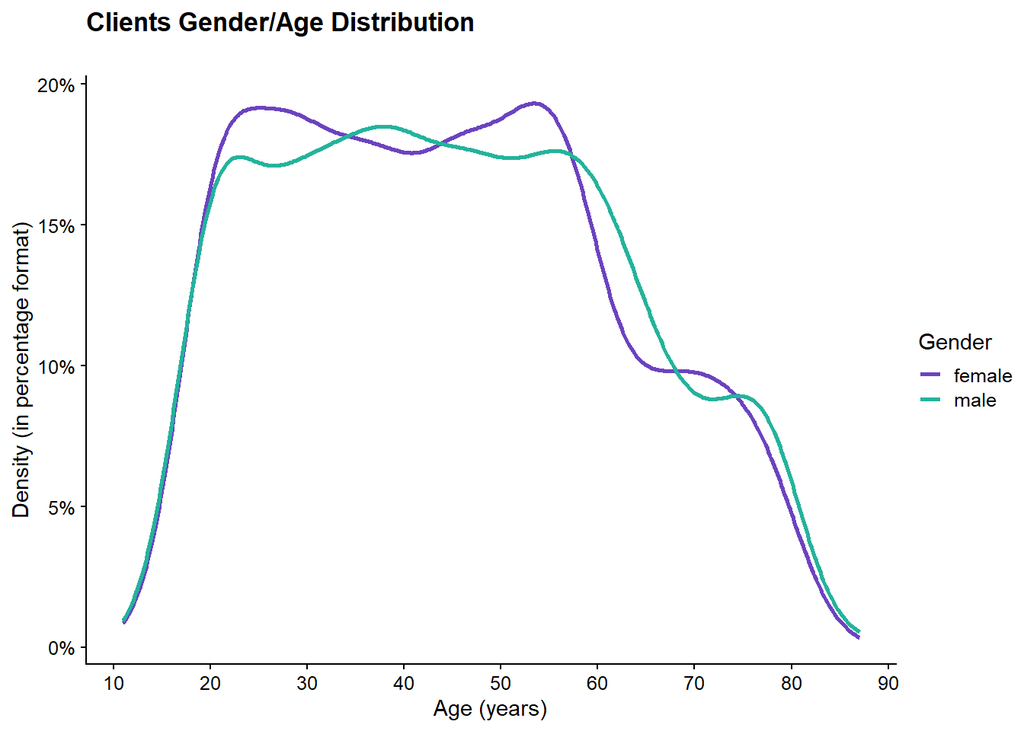

```r
p <- ggplot(clientOK, aes(x = age, fill = gender, color = gender))
p +
  geom_line(stat = "density", lwd = 1) +
  scale_x_continuous(breaks = seq(10, 90, 10)) +
  scale_y_continuous(labels = scales::percent_format(accuracy = TRUE, scale = 1000)) +
  theme(legend.position = "right", ) +
  scale_color_manual(name = "Gender", values = gender_palette) +
  labs(y = "Density (in percentage format)", x = "Age (years)", title = "Clients Gender/Age Distribution", subtitle = "")
```

From the density plot we can see that most clients are between 18 and 63 years old. At the right end of this kind of distorted lighted skewed normal curve there is although a noteworthy group of older clients that we must have into account.

We double check what we have seen in the plot looking closer at the figures.

```r
clients_age_bin <- clientOK %>%
  mutate(age_bins = cut(x = age, breaks = c(10, 18, 25, 35, 45, 55, 65, 75, 88))) %>%
  group_by(age_bins) %>%
  summarise(age_bins_count = n())
clients_age_bin
```

| age_bins | age_bins_count |
| --- | --- |
| (10,18] | 166 |
| (18,25] | 721 |
| (25,35] | 977 |
| (35,45] | 957 |
| (45,55] | 978 |
| (55,65] | 807 |
| (65,75] | 506 |
| (75,88] | 257 |

With this information on our hands, we can now build proper bins for our age distribution.

```sql
SELECT
  new_client.gender,
  new_client.age_group
FROM (
      SELECT
        CASE
          WHEN (MOD(client.birth_number / 100, 100) > 50) THEN 'female'
          ELSE 'male'
        END as gender,
        CASE
          WHEN
            (
              CASE
                WHEN MOD(client.birth_number / 100, 100) > 50 THEN (981231-(client.birth_number-5000))/10000
                ELSE (981231-client.birth_number)/10000
              END <= 25) THEN '<25'
          WHEN
            (
              CASE
                WHEN MOD(client.birth_number / 100, 100) > 50 THEN (981231-(client.birth_number-5000))/10000
                ELSE (981231-client.birth_number)/10000
              END <= 35) THEN '26-35'
          WHEN
            (
              CASE
                WHEN MOD(client.birth_number / 100, 100) > 50 THEN (981231-(client.birth_number-5000))/10000
                ELSE (981231-client.birth_number)/10000
              END <= 45) THEN '36-45'
          WHEN
            (
              CASE
                WHEN MOD(client.birth_number / 100, 100) > 50 THEN (981231-(client.birth_number-5000))/10000
                ELSE (981231-client.birth_number)/10000
              END <= 55) THEN '46-55'
          WHEN
            (
              CASE
                WHEN MOD(client.birth_number / 100, 100) > 50 THEN (981231-(client.birth_number-5000))/10000
                ELSE (981231-client.birth_number)/10000
              END <= 65) THEN '56-65'
        ELSE '65+'
        END as age_group,
         client.client_id
      FROM client
    ) new_client
```

```r
head(gender_age_dataset)
```

| gender | age_group |
| --- | --- |
| female | 26-35 |
| male | 46-55 |
| female | 56-65 |
| male | 36-45 |
| female | 36-45 |
| male | 65+ |

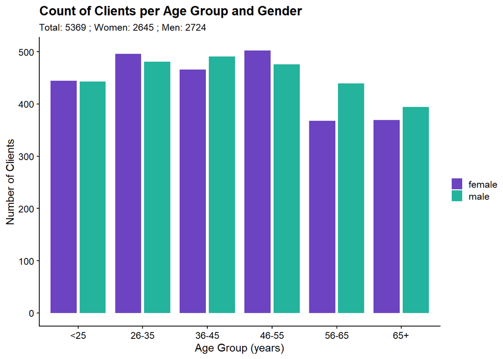

```r
p <- ggplot(gender_age_dataset, aes(x = age_group, fill = gender))
p +
  geom_bar(position = "dodge2") +
  theme(legend.position = "right") +
  labs(x = 'Age Group (years)', y = 'Number of Clients', fill ='', title = "Count of Clients per Age Group and Gender", subtitle = paste("Total:", pct_client_gender$n[1] + pct_client_gender$n[2], ";" , "Women:", pct_client_gender$n[1], ";", "Men:", pct_client_gender$n[2])) +
  scale_fill_manual(values = gender_palette)
```

The most of our clients are between 25 and 55 years old. They are almost equally distributed per gender.

## Card details

Next we want to focus our attention in one of the products that the bank offers to his clients: credit cards. We are going to use again our gender/age demographic variables to carry out our analysis of the credit card relation.

As before, first we want to know how the age distribution of our clients with a credit card looks.

```sql
SELECT DISTINCT client.client_id, district_id, birth_number,
       CASE
         WHEN MOD(birth_number / 100, 100) > 50 THEN To_date(
         To_char(( birth_number
                   - 5000 + 19000000 ), '99999999'), 'YYYYMMDD')
         ELSE To_date(To_char(birth_number + 19000000, '99999999'), 'YYYYMMDD')
       END as birth_date,
       CASE
         WHEN MOD(birth_number / 100, 100) > 50 THEN 'female'
         ELSE 'male'
       END as gender,
       CASE
         WHEN MOD(birth_number / 100, 100) > 50 THEN Age(
         '1998-12-31 00:00:00' :: timestamp, To_date(To_char(( birth_number - 5000 + 19000000), '99999999'), 'YYYYMMDD'))
         ELSE Age('1998-12-31 00:00:00' :: timestamp, To_date(
                     To_char(birth_number + 19000000, '99999999'), 'YYYYMMDD'))
       END as age_years,
       Extract(YEAR from (age ('1998-12-31',
               to_date(to_char(19000000 + CASE
             WHEN (CASE  WHEN MOD(birth_number / 100, 100) > 50 THEN 'female'
             ELSE 'male' END)  = 'female' THEN birth_number - 5000
             ELSE birth_number
             END,'99999999' ), 'YYYYMMDD')))) age
FROM client
JOIN disp ON client.client_id = disp.client_id
JOIN card ON disp.disp_id = card.disp_id
```

```r
head(clients_cards_dataset_age_distribution)
```

| client_id | district_id | birth_number | birth_date | gender | age_years | age |
| --- | --- | --- | --- | --- | --- | --- |
| 9 | 60 | 351016 | 1935-10-16 | male | 63 years 2 mons 15 days | 63 |
| 19 | 47 | 421228 | 1942-12-28 | male | 56 years 3 days | 56 |
| 41 | 22 | 680827 | 1968-08-27 | male | 30 years 4 mons 4 days | 30 |
| 42 | 68 | 350817 | 1935-08-17 | male | 63 years 4 mons 14 days | 63 |
| 51 | 36 | 796202 | 1979-12-02 | female | 19 years 29 days | 19 |
| 56 | 21 | 600331 | 1960-03-31 | male | 38 years 9 mons | 38 |

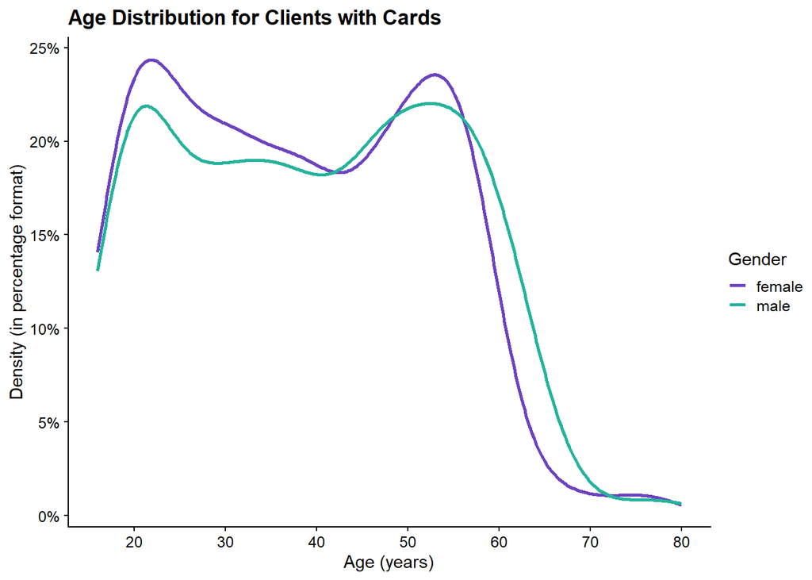

```r
p <- ggplot(clients_cards_dataset_age_distribution, aes(x = age, fill = gender, color = gender))
p +
  geom_line(stat = "density", lwd = 1) +
  scale_x_continuous(breaks = seq(10, 90, 10)) +
  scale_y_continuous(labels = scales::percent_format(accuracy = TRUE, scale = 1000)) +
  theme(legend.position = "right") +
  labs(y ="Density (in percentage format)", x = "Age (years)", title = "Age Distribution for Clients with Cards") +
  scale_color_manual(name = "Gender", values = gender_palette)
```

```r
card_age_bin <- clients_cards_dataset_age_distribution %>%
  mutate(age_bins = cut(x = age, breaks = c(10, 18, 25, 35, 45, 55, 65, 75, 88))) %>%
  group_by(age_bins) %>%
  summarise(age_bins_count = n())
card_age_bin
```

| age_bins | age_bins_count |
| --- | --- |
| (10,18] | 52 |
| (18,25] | 162 |
| (25,35] | 177 |
| (35,45] | 159 |
| (45,55] | 199 |
| (55,65] | 128 |
| (65,75] | 9 |
| (75,88] | 6 |

Both plot and summarized figures show us that credit card owners over 65 years old are an exception.

Let´s put all together, card ownership, gender and age groups, to have an overview of the product credit cards.

```sql
SELECT
  new_client.client_id,
  new_client.gender,
  new_client.age_group,
  card.issued,
CASE COUNT(card.card_id)
   WHEN 0 then 'N'
   ELSE 'Y'
   END as has_cards
FROM
  (
    SELECT client.client_id,
      CASE
        WHEN (MOD(client.birth_number / 100, 100) > 50) THEN 'female'
        ELSE 'male'
      END as gender,
        CASE
          WHEN
            (
              CASE
                WHEN MOD(client.birth_number / 100, 100) > 50 THEN (981231-(client.birth_number-5000))/10000
                ELSE (981231-client.birth_number)/10000
              END <= 25) THEN '<25'
          WHEN
            (
              CASE
                WHEN MOD(client.birth_number / 100, 100) > 50 THEN (981231-(client.birth_number-5000))/10000
                ELSE (981231-client.birth_number)/10000
              END <= 35) THEN '26-35'
          WHEN
            (
              CASE
                WHEN MOD(client.birth_number / 100, 100) > 50 THEN (981231-(client.birth_number-5000))/10000
                ELSE (981231-client.birth_number)/10000
              END <= 45) THEN '36-45'
          WHEN
            (
              CASE
                WHEN MOD(client.birth_number / 100, 100) > 50 THEN (981231-(client.birth_number-5000))/10000
                ELSE (981231-client.birth_number)/10000
              END <= 55) THEN '46-55'
        ELSE '55-65'
        END as age_group,
      client.district_id
FROM client) new_client
JOIN disp ON new_client.client_id = disp.client_id
LEFT JOIN card ON disp.disp_id = card.disp_id
GROUP BY
new_client.client_id,
new_client.gender,
new_client.age_group,
card.issued
ORDER BY new_client.client_id
```

```r
head(clients_cards_dataset)
```

| client_id | gender | age_group | issued | has_cards |
| --- | --- | --- | --- | --- |
| 1 | female | 26-35 | NA | N |
| 2 | male | 46-55 | NA | N |
| 3 | female | 55-65 | NA | N |
| 4 | male | 36-45 | NA | N |
| 5 | female | 36-45 | NA | N |
| 6 | male | 55-65 | NA | N |

```r
clients_cards_summarized <- clients_cards_dataset %>%
  group_by(has_cards) %>%
  summarize(N = n()) %>%
  mutate(freq = N / sum(N), pct = round((freq*100), 0))
clients_cards_summarized
```

| has_cards | N | freq | pct |
| --- | --- | --- | --- |
| N | 4477 | 0.8338611 | 83 |
| Y | 892 | 0.1661389 | 17 |

Some simple summarized statistis let us know that most clients don´t own a credit card (4477/83%).

Let´s focus now on the ones they have this product (892/17%).

```r
clients_with_cards <- clients_cards_dataset %>%
  filter(has_cards == 'Y') %>%
  group_by(age_group) %>%
  summarize(N = n()) %>%
  mutate(freq = N / sum(N), pct = round((freq*100), 0))
clients_with_cards
```

| age_group | N | freq | pct |
| --- | --- | --- | --- |
| <25 | 214 | 0.2399103 | 24 |
| 26-35 | 177 | 0.1984305 | 20 |
| 36-45 | 159 | 0.1782511 | 18 |
| 46-55 | 199 | 0.2230942 | 22 |
| 55-65 | 143 | 0.1603139 | 16 |

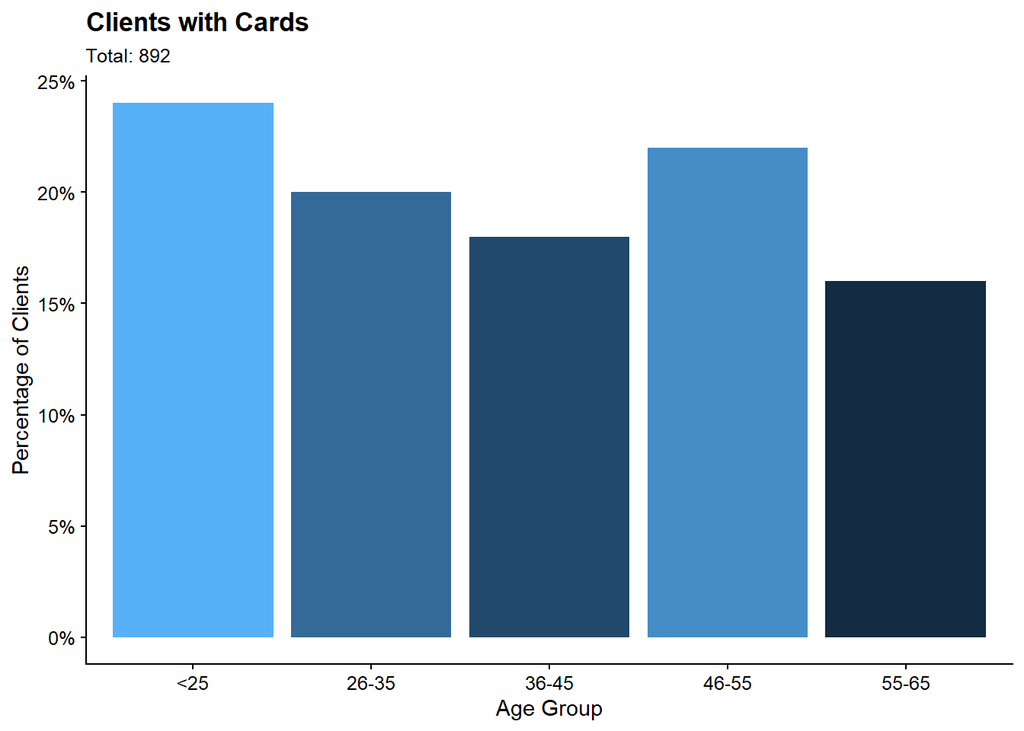

```r
p <- ggplot(clients_with_cards, aes(x = age_group, y = pct, fill = pct))
p +
  geom_bar(position = "dodge2", stat = "identity") +
  scale_y_continuous(labels = scales::percent_format(accuracy = TRUE, scale = 1)) +
  theme(legend.position = "top") +
  labs(x = 'Age Group',y = 'Percentage of Clients', fill = '', title = "Clients with Cards", subtitle = paste("Total:", clients_cards_summarized$N[2])) +
  guides(fill = FALSE)
```

The main group of our clients that are card owners are the youngest one, <25, and the middle age group, 46-55. It seems that clients over 65 years old don´t benefit from this product.

```r
clients_without_cards <- clients_cards_dataset %>%
  filter(has_cards == 'N') %>%
  group_by(age_group) %>%
  summarize(N = n()) %>%
  mutate(freq = N / sum(N), pct = round((freq*100), 0))
clients_without_cards
```

| age_group | N | freq | pct |
| --- | --- | --- | --- |
| <25 | 673 | 0.1503239 | 15 |
| 26-35 | 800 | 0.1786911 | 18 |
| 36-45 | 798 | 0.1782444 | 18 |
| 46-55 | 779 | 0.1740004 | 17 |
| 55-65 | 1427 | 0.3187402 | 32 |

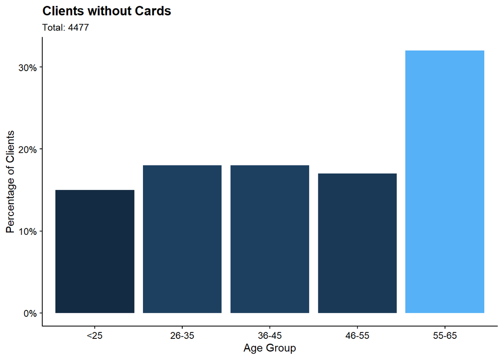

```r
p <- ggplot(clients_without_cards, aes(x = age_group, y = pct, fill = pct, labels = pct))
p +
  geom_bar(position = "dodge2", stat = "identity") +
  scale_y_continuous(labels = scales::percent_format(accuracy = TRUE, scale = 1)) +
  theme(legend.position = "top") +
  labs(x = 'Age Group',y = 'Percentage of Clients', fill ='', title = "Clients without Cards", subtitle = paste("Total:", clients_cards_summarized$N[1])) +
  guides(fill = FALSE)
```

As we know, credit cards are one of the most interesting (profitable) products for banking business. It makes sense to find out the timeline (in months) for an ordinary client since he/she became our customer until he/she purchased a credit card for the first time.

```sql
SELECT
  new_client.client_id,
  new_client.gender,
  new_client.age_group,
  ROUND(CAST((card.issued - account.date) as decimal) / 30)  as lapse_time_months
FROM
  (
    SELECT client.client_id,
      CASE
        WHEN (MOD(client.birth_number / 100, 100) > 50) THEN 'female'
        ELSE 'male'
      END as gender,
        CASE
          WHEN
            (
              CASE
                WHEN MOD(client.birth_number / 100, 100) > 50 THEN (981231-(client.birth_number-5000))/10000
                ELSE (981231-client.birth_number)/10000
              END <= 25) THEN '<25'
          WHEN
            (
              CASE
                WHEN MOD(client.birth_number / 100, 100) > 50 THEN (981231-(client.birth_number-5000))/10000
                ELSE (981231-client.birth_number)/10000
              END <= 35) THEN '26-35'
          WHEN
            (
              CASE
                WHEN MOD(client.birth_number / 100, 100) > 50 THEN (981231-(client.birth_number-5000))/10000
                ELSE (981231-client.birth_number)/10000
              END <= 45) THEN '36-45'
          WHEN
            (
              CASE
                WHEN MOD(client.birth_number / 100, 100) > 50 THEN (981231-(client.birth_number-5000))/10000
                ELSE (981231-client.birth_number)/10000
              END <= 55) THEN '46-55'
        ELSE '55-65'
        END as age_group,
      client.district_id
FROM client) new_client
JOIN disp ON new_client.client_id = disp.client_id
JOIN card ON disp.disp_id = card.disp_id
JOIN account ON account.account_id = disp.account_id
ORDER BY age_group
```

```r
head(clients_cards_account_dataset)
```

| client_id | gender | age_group | lapse_time_months |
| --- | --- | --- | --- |
| 4715 | female | <25 | 39 |
| 510 | male | <25 | 9 |
| 513 | female | <25 | 40 |
| 12986 | female | <25 | 32 |
| 519 | male | <25 | 21 |
| 4680 | female | <25 | 13 |

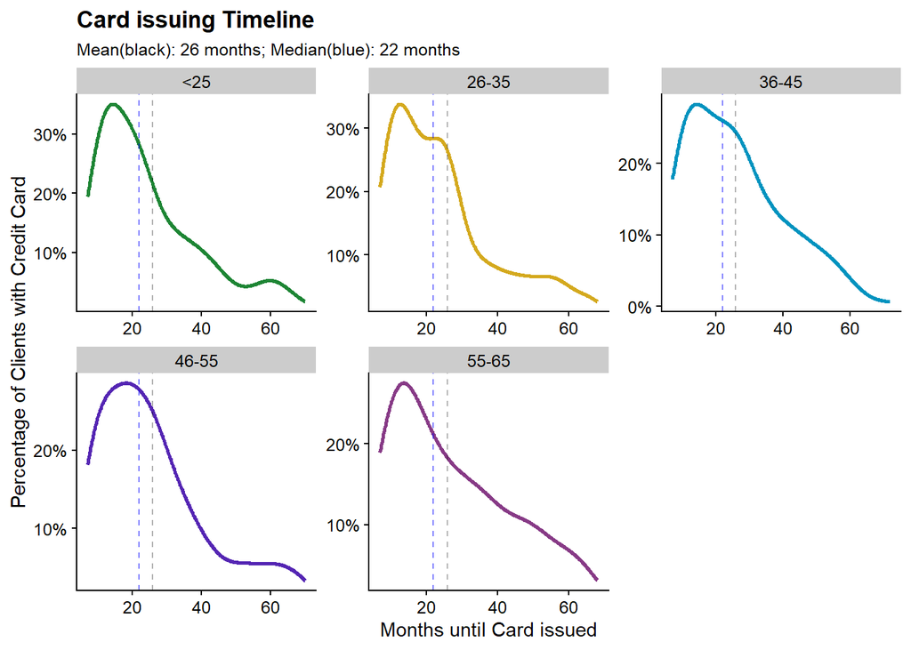

```r
p <- ggplot(clients_cards_account_dataset, aes(x = lapse_time_months, fill = age_group, color = age_group))
p +
  geom_line(stat = "density", lwd = 1) +
  scale_y_continuous(labels = scales::percent_format(accuracy = TRUE, scale = 1000)) +
  labs(x = 'Months until Card issued',y = 'Percentage of Clients with Credit Card', title = "Card issuing Timeline", subtitle = paste("Mean(black):", round(mean(clients_cards_account_dataset$lapse_time_months)), "months;", "Median(blue):", median(clients_cards_account_dataset$lapse_time_months), "months")) +
  geom_vline(aes(xintercept = mean(lapse_time_months)),col = 'black', linetype = "dashed", size = 0.5, alpha = .3) +
  geom_vline(aes(xintercept = median(lapse_time_months)),col = 'blue', linetype = "dashed", size = 0.5, alpha = .5) +
  facet_wrap(~ age_group, scales = "free") +
  scale_color_manual(values = qua_scale_seven) +
  guides(colour = FALSE)
```

## Loan details

Looking at another product that is interesting for our cross-selling strategy, we focus on variables like the current status, the amount and the timeframe (date and duration) of these loans.

As before, we begin looking at and adjusting accordingly the age distribution.

```sql
SELECT DISTINCT client.client_id, birth_number,
       CASE
         WHEN MOD(birth_number / 100, 100) > 50 THEN To_date(
         To_char(( birth_number
                   - 5000 + 19000000 ), '99999999'), 'YYYYMMDD')
         ELSE To_date(To_char(birth_number + 19000000, '99999999'), 'YYYYMMDD')
       END as birth_date,
       CASE
         WHEN MOD(birth_number / 100, 100) > 50 THEN 'female'
         ELSE 'male'
       END as gender,
       CASE
         WHEN MOD(birth_number / 100, 100) > 50 THEN Age(
         '1998-12-31 00:00:00' :: timestamp, To_date(To_char(( birth_number - 5000 + 19000000), '99999999'), 'YYYYMMDD'))
         ELSE Age('1998-12-31 00:00:00' :: timestamp, To_date(
                     To_char(birth_number + 19000000, '99999999'), 'YYYYMMDD'))
       END as age_years,
       Extract(YEAR from (age ('1998-12-31',
               to_date(to_char(19000000 + CASE
             WHEN (CASE  WHEN MOD(birth_number / 100, 100) > 50 THEN 'female'
             ELSE 'male' END)  = 'female' THEN birth_number - 5000
             ELSE birth_number
             END,'99999999' ), 'YYYYMMDD')))) age
FROM client
JOIN disp ON client.client_id = disp.client_id
JOIN account ON disp.account_id = account.account_id
JOIN loan ON account.account_id = loan.account_id
```

```r
head(loan_details_dataset_age_distribution)
```

| client_id | birth_number | birth_date | gender | age_years | age |
| --- | --- | --- | --- | --- | --- |
| 2 | 450204 | 1945-02-04 | male | 53 years 10 mons 27 days | 53 |
| 3 | 406009 | 1940-10-09 | female | 58 years 2 mons 22 days | 58 |
| 25 | 395423 | 1939-04-23 | female | 59 years 8 mons 8 days | 59 |
| 31 | 620209 | 1962-02-09 | male | 36 years 10 mons 22 days | 36 |
| 45 | 520826 | 1952-08-26 | male | 46 years 4 mons 5 days | 46 |
| 46 | 405130 | 1940-01-30 | female | 58 years 11 mons 1 day | 58 |

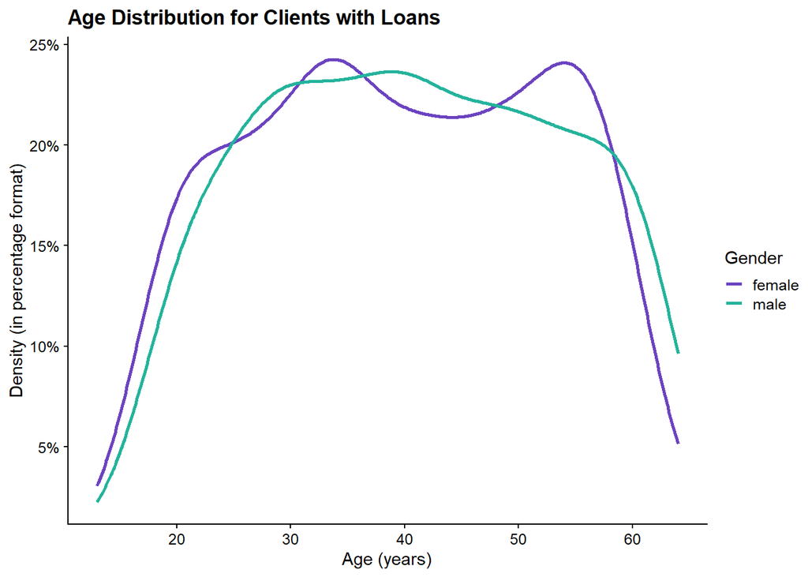

```r
p <- ggplot(loan_details_dataset_age_distribution, aes(x = age, fill = gender, color = gender))
p +
  geom_line(stat = "density", lwd = 1) +
  scale_y_continuous(labels = scales::percent_format(accuracy = TRUE, scale = 1000)) +
  scale_x_continuous(breaks = seq(10, 90, 10)) +
  theme(legend.position = "right") +
  scale_color_manual(name = "Gender", values = gender_palette) +
  labs(y = "Density (in percentage format)", x = "Age (years)", title = "Age Distribution for Clients with Loans")
```

```r
loan_age_bin <- loan_details_dataset_age_distribution %>%
  mutate(age_bins = cut(x = age, breaks = c(10, 18, 25, 35, 45, 55, 65))) %>%
  group_by(age_bins) %>%
  summarise(age_bins_count = n())
loan_age_bin
```

| age_bins | age_bins_count |
| --- | --- |
| (10,18] | 21 |
| (18,25] | 114 |
| (25,35] | 196 |
| (35,45] | 183 |
| (45,55] | 185 |
| (55,65] | 128 |

```sql
SELECT DISTINCT
  loan_id,
  loan.account_id,
  loan.date as loan_date,
  amount as loan_amount,
  duration,
  payments as monthly_payment,
  ROUND(CAST((loan.date - account.date) as decimal) / 30)  as lapse_time_months,
  CASE
    WHEN status ='A' THEN 'finished, no problems'
    WHEN status ='B' THEN 'finished, loan not payed'
    WHEN status ='C' THEN 'running contract, OK so far'
    WHEN status ='D' THEN 'running contract, client in debt'
    END as "loan_status",
        CASE
          WHEN
            (
              CASE
                WHEN MOD(client.birth_number / 100, 100) > 50 THEN (981231-(client.birth_number-5000))/10000
                ELSE (981231-client.birth_number)/10000
              END <= 25) THEN '<25'
          WHEN
            (
              CASE
                WHEN MOD(client.birth_number / 100, 100) > 50 THEN (981231-(client.birth_number-5000))/10000
                ELSE (981231-client.birth_number)/10000
              END <= 35) THEN '26-35'
          WHEN
            (
              CASE
                WHEN MOD(client.birth_number / 100, 100) > 50 THEN (981231-(client.birth_number-5000))/10000
                ELSE (981231-client.birth_number)/10000
              END <= 45) THEN '36-45'
          WHEN
            (
              CASE
                WHEN MOD(client.birth_number / 100, 100) > 50 THEN (981231-(client.birth_number-5000))/10000
                ELSE (981231-client.birth_number)/10000
              END <= 55) THEN '46-55'
        ELSE '55-65'
        END as age_group
FROM loan
JOIN account ON loan.account_id=account.account_id
JOIN disp ON account.account_id=disp.account_id
JOIN client ON disp.client_id=client.client_id
WHERE disp.type = 'OWNER'
ORDER BY loan_amount desc
```

```r
head(loan_details_dataset)
```

| loan_id | account_id | loan_date | loan_amount | duration | monthly_payment | lapse_time_months | loan_status | age_group |
| --- | --- | --- | --- | --- | --- | --- | --- | --- |
| 6534 | 7542 | 1997-10-19 | 590820 | 60 | 9847 | 17 | running contract, OK so far | 26-35 |
| 6791 | 8926 | 1998-01-23 | 566640 | 60 | 9444 | 10 | running contract, OK so far | 26-35 |
| 5447 | 2335 | 1997-11-12 | 541200 | 60 | 9020 | 20 | running contract, client in debt | 46-55 |
| 5132 | 817 | 1995-02-17 | 538500 | 60 | 8975 | 11 | running contract, OK so far | 36-45 |
| 5569 | 2936 | 1998-01-20 | 504000 | 60 | 8400 | 22 | running contract, OK so far | 26-35 |
| 6436 | 7049 | 1998-05-22 | 495180 | 60 | 8253 | 7 | running contract, OK so far | <25 |

```r
loan_details_status <- loan_details_dataset %>%
  group_by(loan_status) %>%
  summarize(N = n()) %>%
  mutate(freq = N / sum(N), pct = round((freq*100), 0))
loan_details_status
```

| loan_status | N | freq | pct |
| --- | --- | --- | --- |
| finished, loan not payed | 31 | 0.0454545 | 5 |
| finished, no problems | 203 | 0.2976540 | 30 |
| running contract, client in debt | 45 | 0.0659824 | 7 |
| running contract, OK so far | 403 | 0.5909091 | 59 |

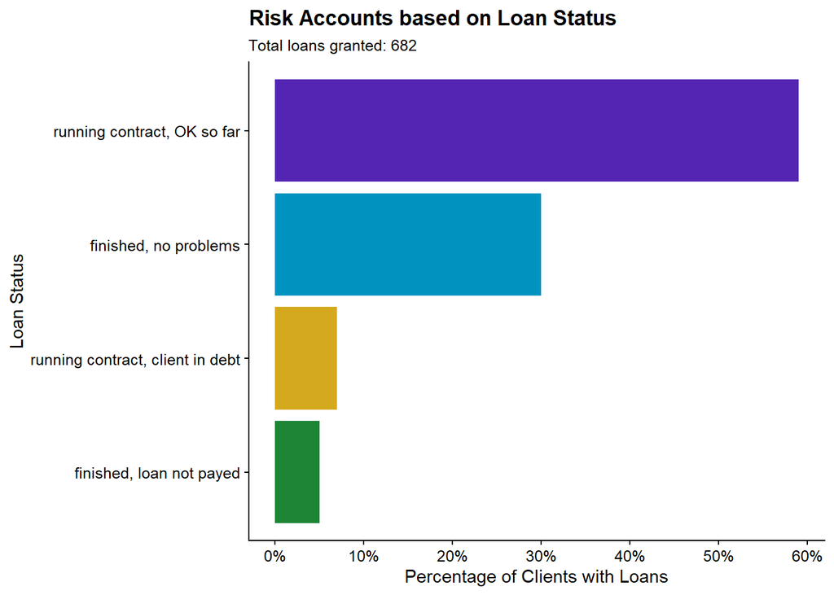

```r
loan_details_arranged <- loan_details_status %>%
  arrange(pct) %>%
  mutate(loan_status = factor(loan_status, levels =loan_status))

p <- ggplot(loan_details_arranged, aes(x = loan_status, y = pct, fill = loan_status))
p +
  geom_bar(stat = "identity") +
  scale_y_continuous(labels = scales::percent_format(accuracy = TRUE, scale = 1), breaks = seq(0, 60, 10)) +
  labs(x = 'Loan Status', y = 'Percentage of Clients with Loans', title = "Risk Accounts based on Loan Status", subtitle = paste("Total loans granted:", sum(loan_details_status$N))) +
  guides(fill = FALSE) +
  scale_fill_manual(values = qua_scale_seven) +
  coord_flip()
```

Although we have almost a 60% of our clients we can consider good “payers”, the defaulting rate among our clients with negative balance (clients with running contract that they are in red and finished unpayed contracts) is schockingly high: 11%.

Let´s see how it looks per age group.

```r
loan_details_age_group <- loan_details_dataset %>%
  group_by(age_group, loan_status) %>%
  summarize(N = n()) %>%
  mutate(freq = N / sum(N), pct = round((freq*100), 0))
loan_details_age_arranged <- loan_details_age_group %>%
  arrange(pct) %>%
  mutate(loan_status = factor(loan_status, levels = loan_status))
loan_details_age_arranged
```

| age_group | loan_status | N | freq | pct |
| --- | --- | --- | --- | --- |
| 26-35 | finished, loan not payed | 5 | 0.0297619 | 3 |
| 36-45 | finished, loan not payed | 5 | 0.0326797 | 3 |
| <25 | finished, loan not payed | 5 | 0.0462963 | 5 |
| 46-55 | running contract, client in debt | 8 | 0.0519481 | 5 |
| 36-45 | running contract, client in debt | 9 | 0.0588235 | 6 |
| 46-55 | finished, loan not payed | 10 | 0.0649351 | 6 |
| 55-65 | finished, loan not payed | 6 | 0.0606061 | 6 |
| 26-35 | running contract, client in debt | 12 | 0.0714286 | 7 |
| 55-65 | running contract, client in debt | 7 | 0.0707071 | 7 |
| <25 | running contract, client in debt | 9 | 0.0833333 | 8 |
| 46-55 | finished, no problems | 42 | 0.2727273 | 27 |
| <25 | finished, no problems | 30 | 0.2777778 | 28 |
| 26-35 | finished, no problems | 51 | 0.3035714 | 30 |
| 36-45 | finished, no problems | 48 | 0.3137255 | 31 |
| 55-65 | finished, no problems | 32 | 0.3232323 | 32 |
| 55-65 | running contract, OK so far | 54 | 0.5454545 | 55 |
| <25 | running contract, OK so far | 64 | 0.5925926 | 59 |
| 36-45 | running contract, OK so far | 91 | 0.5947712 | 59 |
| 26-35 | running contract, OK so far | 100 | 0.5952381 | 60 |
| 46-55 | running contract, OK so far | 94 | 0.6103896 | 61 |

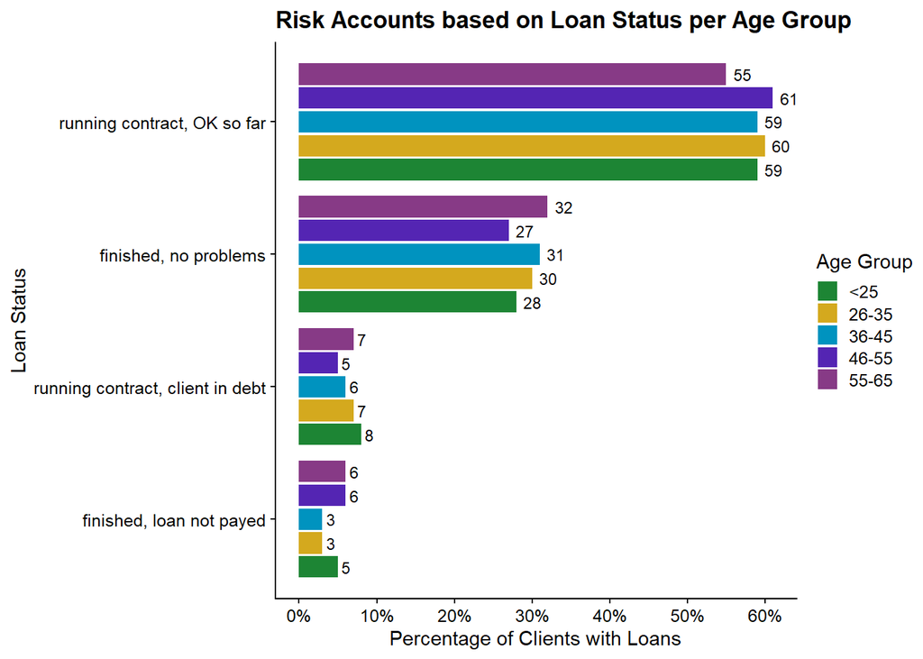

```r
p <- ggplot(loan_details_age_arranged, aes(x = loan_status, y = pct, fill = age_group))
p +
  geom_col(position = "dodge2") +
  scale_y_continuous(labels = scales::percent_format(accuracy = TRUE, scale = 1), breaks = seq(0, 60, 10)) +
  labs(x = 'Loan Status', y = "Percentage of Clients with Loans", title = "Risk Accounts based on Loan Status per Age Group") +
  geom_text(aes(x = loan_status, label = pct), position = position_dodge(width = 0.9), hjust = -0.40, size = rel(3)) +
  theme(legend.position = "right") +
  scale_fill_manual(name = "Age Group", values = qua_scale_seven) +
  coord_flip()
```

Lets get now a big picture of loans. We want to summarize some relevant statistic information (median, quartiles, outliers) grouped by loan status.

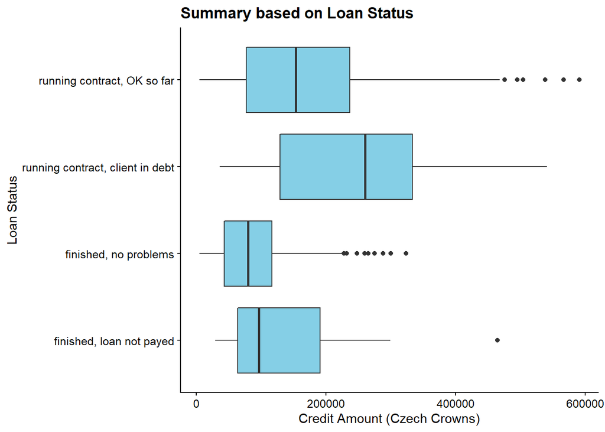

```r
p <- ggplot(loan_details_dataset, aes(x = loan_details_dataset$loan_status, y = loan_details_dataset$loan_amount))
p +
  geom_boxplot(fill = "#85CFE6") +
  labs(x = 'Loan Status', y = "Credit Amount (Czech Crowns)", title = "Summary based on Loan Status") +
  coord_flip()
```

As we can see, the current clients with a running loan that they are in red have in general bigger loans than the ones they are up to day (with some exceptions; see outliers). Maybe we can review the conditions of those loans or offer a new ones to make our relation with these clients stronger and long-lasting.

The next question we want to answer is about the loan terms that our clients requested.

```r
loan_details_term <- loan_details_dataset %>%
  group_by(duration, loan_status) %>%
  summarize(N = n()) %>%
  mutate(freq = N / sum(N), pct = round((freq*100), 0))
loan_details_term
```

| duration | loan_status | N | freq | pct |
| --- | --- | --- | --- | --- |
| 12 | finished, loan not payed | 10 | 0.0763359 | 8 |
| 12 | finished, no problems | 93 | 0.7099237 | 71 |
| 12 | running contract, client in debt | 1 | 0.0076336 | 1 |
| 12 | running contract, OK so far | 27 | 0.2061069 | 21 |
| 24 | finished, loan not payed | 11 | 0.0797101 | 8 |
| 24 | finished, no problems | 64 | 0.4637681 | 46 |
| 24 | running contract, client in debt | 6 | 0.0434783 | 4 |
| 24 | running contract, OK so far | 57 | 0.4130435 | 41 |
| 36 | finished, loan not payed | 7 | 0.0538462 | 5 |
| 36 | finished, no problems | 32 | 0.2461538 | 25 |
| 36 | running contract, client in debt | 8 | 0.0615385 | 6 |
| 36 | running contract, OK so far | 83 | 0.6384615 | 64 |
| 48 | finished, loan not payed | 2 | 0.0144928 | 1 |
| 48 | finished, no problems | 11 | 0.0797101 | 8 |
| 48 | running contract, client in debt | 14 | 0.1014493 | 10 |
| 48 | running contract, OK so far | 111 | 0.8043478 | 80 |
| 60 | finished, loan not payed | 1 | 0.0068966 | 1 |
| 60 | finished, no problems | 3 | 0.0206897 | 2 |
| 60 | running contract, client in debt | 16 | 0.1103448 | 11 |
| 60 | running contract, OK so far | 125 | 0.8620690 | 86 |

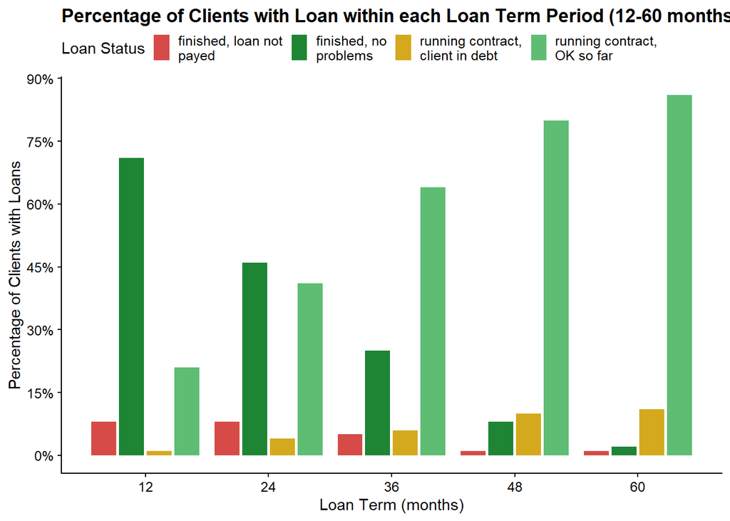

```r
p <- ggplot(loan_details_term, aes(x = duration, y = pct, fill = str_wrap(loan_status, 18)))
p +
  geom_col(position = "dodge2") +
  scale_x_continuous(breaks = c(12, 24, 36, 48, 60)) +
  scale_y_continuous(labels = scales::percent_format(accuracy = TRUE, scale = 1), breaks = seq(0, 100, 15)) +
  labs(x = 'Loan Term (months)', y = "Percentage of Clients with Loans", title = "Percentage of Clients with Loan within each Loan Term Period (12-60 months)") +
  theme(legend.position = "top") +
  scale_fill_manual(name = "Loan Status", values = qua_scale_four_pos_neg)
```

We are focusing now on the variable time. We want to know the timeline since a customer opened an account and got a loan.

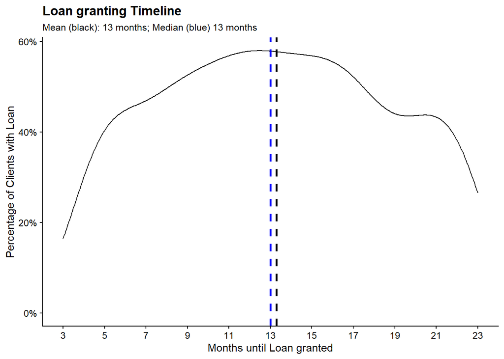

```r
p <- ggplot(loan_details_dataset, aes(x = lapse_time_months))
p +
  geom_density() +
  scale_y_continuous(labels = scales::percent_format(accuracy = TRUE, scale = 1000)) +
  scale_x_continuous(breaks = seq(3, 23, 2)) +
  labs(x = "Months until Loan granted", y = "Percentage of Clients with Loan", fill='', title = "Loan granting Timeline", subtitle = paste("Mean (black):", round(mean(loan_details_dataset$lapse_time_months)), "months;", "Median (blue)", median(loan_details_dataset$lapse_time_months), "months")) +
  geom_vline(aes(xintercept = mean(lapse_time_months)),col = 'black', linetype = "dashed", size = 1) +
  geom_vline(aes(xintercept = median(lapse_time_months)),col = 'blue', linetype = "dashed", size = 1)
```

We found a distribution that looks like a normal shape and has mean and median around 13 months.

Next we want to find out how many clients have/had the two products we are interested most: card and loan.

```sql
SELECT DISTINCT
  CASE
    WHEN status ='A' THEN 'finished, no problems'
    WHEN status ='B' THEN 'finished, loan not payed'
    WHEN status ='C' THEN 'running contract, OK so far'
    WHEN status ='D' THEN 'running contract, client in debt'
    END as "loan_status",
        CASE
          WHEN
            (
              CASE
                WHEN MOD(client.birth_number / 100, 100) > 50 THEN (981231-(client.birth_number-5000))/10000
                ELSE (981231-client.birth_number)/10000
              END <= 25) THEN '<25'
          WHEN
            (
              CASE
                WHEN MOD(client.birth_number / 100, 100) > 50 THEN (981231-(client.birth_number-5000))/10000
                ELSE (981231-client.birth_number)/10000
              END <= 35) THEN '26-35'
          WHEN
            (
              CASE
                WHEN MOD(client.birth_number / 100, 100) > 50 THEN (981231-(client.birth_number-5000))/10000
                ELSE (981231-client.birth_number)/10000
              END <= 45) THEN '36-45'
          WHEN
            (
              CASE
                WHEN MOD(client.birth_number / 100, 100) > 50 THEN (981231-(client.birth_number-5000))/10000
                ELSE (981231-client.birth_number)/10000
              END <= 55) THEN '46-55'
        ELSE '55-65'
        END as age_group,
COUNT(*)
FROM loan
JOIN account ON loan.account_id=account.account_id
JOIN disp ON account.account_id=disp.account_id
JOIN client ON disp.client_id=client.client_id
JOIN card ON disp.disp_id=card.disp_id
WHERE disp.type = 'OWNER'
GROUP BY
  CASE
    WHEN status ='A' THEN 'finished, no problems'
    WHEN status ='B' THEN 'finished, loan not payed'
    WHEN status ='C' THEN 'running contract, OK so far'
    WHEN status ='D' THEN 'running contract, client in debt'
    END,
CASE
  WHEN (
              CASE
                WHEN MOD(client.birth_number / 100, 100) > 50 THEN (981231-(client.birth_number-5000))/10000
                ELSE (981231-client.birth_number)/10000
              END <= 25) THEN '<25'
          WHEN
            (
              CASE
                WHEN MOD(client.birth_number / 100, 100) > 50 THEN (981231-(client.birth_number-5000))/10000
                ELSE (981231-client.birth_number)/10000
              END <= 35) THEN '26-35'
          WHEN
            (
              CASE
                WHEN MOD(client.birth_number / 100, 100) > 50 THEN (981231-(client.birth_number-5000))/10000
                ELSE (981231-client.birth_number)/10000
              END <= 45) THEN '36-45'
          WHEN
            (
              CASE
                WHEN MOD(client.birth_number / 100, 100) > 50 THEN (981231-(client.birth_number-5000))/10000
                ELSE (981231-client.birth_number)/10000
              END <= 55) THEN '46-55'
        ELSE '55-65'
  END
```

```r
head(count_card_loan_clients)
```

| loan_status | age_group | count |
| --- | --- | --- |
| finished, loan not payed | <25 | 1 |
| finished, loan not payed | 46-55 | 1 |
| finished, no problems | <25 | 12 |
| finished, no problems | 26-35 | 17 |
| finished, no problems | 36-45 | 11 |
| finished, no problems | 46-55 | 8 |

```r
sum(count_card_loan_clients$count)
```

```
## [1] 170
```

As we can see, just 170 from our 3631 “owner” clients have/had both services. That means that there is a lot of potential for our cross-selling campaign. Let’s check out how look like the loan status from clients that at the same time are card owners.

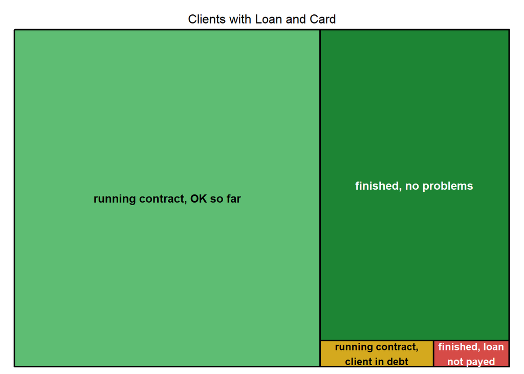

```r
count_card_loan_clients %>%
  treemap(
        index = c("loan_status"),
        vSize = "count",
        palette = qua_scale_four_pos_neg,
        title = "Clients with Loan and Card",
        fontsize.title = 12
        )
```

And how look like the picture per age group?

```sql
SELECT DISTINCT
  loan_id,
  loan.account_id,
  loan.date as loan_date,
  amount as loan_amount,
  duration,
  payments as monthly_payment,
  card.disp_id,
  card.issued,
  CASE
    WHEN status ='A' THEN 'finished, no problems'
    WHEN status ='B' THEN 'finished, loan not payed'
    WHEN status ='C' THEN 'running contract, OK so far'
    WHEN status ='D' THEN 'running contract, client in debt'
    END as "loan_status",
  CASE
      WHEN (
            CASE
              WHEN MOD(client.birth_number / 100, 100) > 50 THEN (981231-(client.birth_number-5000))/10000
              ELSE (981231-client.birth_number)/10000
            END  <= 25) THEN '<25'
      WHEN (
            CASE
              WHEN MOD(client.birth_number / 100, 100) > 50 THEN (981231-(client.birth_number-5000))/10000
              ELSE (981231-client.birth_number)/10000
            END  <= 25) THEN '25-35'
      WHEN (
            CASE
              WHEN MOD(client.birth_number / 100, 100) > 50 THEN (981231-(client.birth_number-5000))/10000
              ELSE (981231-client.birth_number)/10000
            END  <= 35) THEN '36-45'
      WHEN (
            CASE
              WHEN MOD(client.birth_number / 100, 100) > 50 THEN (981231-(client.birth_number-5000))/10000
              ELSE (981231-client.birth_number)/10000
            END  <= 45) THEN '46-55'
    ELSE '56-65'
      END as age_group
FROM loan
JOIN account ON loan.account_id=account.account_id
JOIN disp ON account.account_id=disp.account_id
JOIN client ON disp.client_id=client.client_id
JOIN card ON disp.disp_id=card.disp_id
WHERE disp.type = 'OWNER'
ORDER BY loan_amount desc
```

```r
head(loan_card_details_dataset)
```

| loan_id | account_id | loan_date | loan_amount | duration | monthly_payment | disp_id | issued | loan_status | age_group |
| --- | --- | --- | --- | --- | --- | --- | --- | --- | --- |
| 6436 | 7049 | 1998-05-22 | 495180 | 60 | 8253 | 8506 | 1998-10-16 | running contract, OK so far | <25 |
| 6415 | 6950 | 1997-02-12 | 475680 | 48 | 9910 | 8392 | 1998-08-16 | running contract, OK so far | 36-45 |
| 5043 | 339 | 1997-12-25 | 468060 | 60 | 7801 | 414 | 1998-02-02 | running contract, OK so far | 56-65 |
| 5561 | 2910 | 1998-08-29 | 437460 | 60 | 7291 | 3517 | 1998-09-03 | running contract, OK so far | 46-55 |
| 7101 | 10297 | 1996-11-18 | 421008 | 48 | 8771 | 12354 | 1998-11-30 | running contract, OK so far | 46-55 |
| 7154 | 10520 | 1996-12-05 | 417600 | 60 | 6960 | 12635 | 1996-07-17 | running contract, OK so far | 36-45 |

```r
loan_card_details_age_group <- loan_card_details_dataset %>%
  group_by(age_group, loan_status) %>%
  summarize(N = n()) %>%
  mutate(freq = N / sum(N), pct = round((freq*100), 0))
loan_card_details_age_group_arranged <- loan_card_details_age_group %>%
  arrange(pct) %>%
  mutate(loan_status = factor(loan_status, levels = loan_status))
loan_card_details_age_group_arranged
```

| age_group | loan_status | N | freq | pct |
| --- | --- | --- | --- | --- |
| 56-65 | finished, loan not payed | 1 | 0.0151515 | 2 |
| 56-65 | running contract, client in debt | 1 | 0.0151515 | 2 |
| <25 | finished, loan not payed | 1 | 0.0294118 | 3 |
| <25 | running contract, client in debt | 1 | 0.0294118 | 3 |
| 36-45 | running contract, client in debt | 1 | 0.0263158 | 3 |
| 56-65 | finished, no problems | 20 | 0.3030303 | 30 |
| 46-55 | finished, no problems | 11 | 0.3437500 | 34 |
| <25 | finished, no problems | 12 | 0.3529412 | 35 |
| 36-45 | finished, no problems | 17 | 0.4473684 | 45 |
| 36-45 | running contract, OK so far | 20 | 0.5263158 | 53 |
| <25 | running contract, OK so far | 20 | 0.5882353 | 59 |
| 46-55 | running contract, OK so far | 21 | 0.6562500 | 66 |
| 56-65 | running contract, OK so far | 44 | 0.6666667 | 67 |

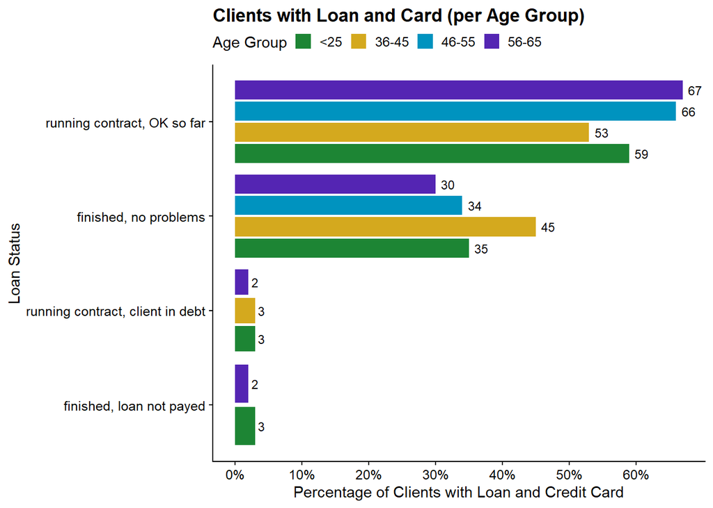

```r
p <- ggplot(loan_card_details_age_group_arranged, aes(x = loan_status, y = pct, fill = age_group))
p +
  geom_col(position = "dodge2") +
  scale_y_continuous(labels = scales::percent_format(accuracy = TRUE, scale = 1), breaks = seq(0, 60, 10)) +
  labs(x = 'Loan Status', y = "Percentage of Clients with Loan and Credit Card", title = "Clients with Loan and Card (per Age Group)") +
  geom_text(aes(x = loan_status, label = pct), position = position_dodge(width = 0.9), hjust = -0.40, size = rel(3)) +
  theme(legend.position = "top") +
  scale_fill_manual(name = "Age Group", values = qua_scale_seven) +
  coord_flip()
```

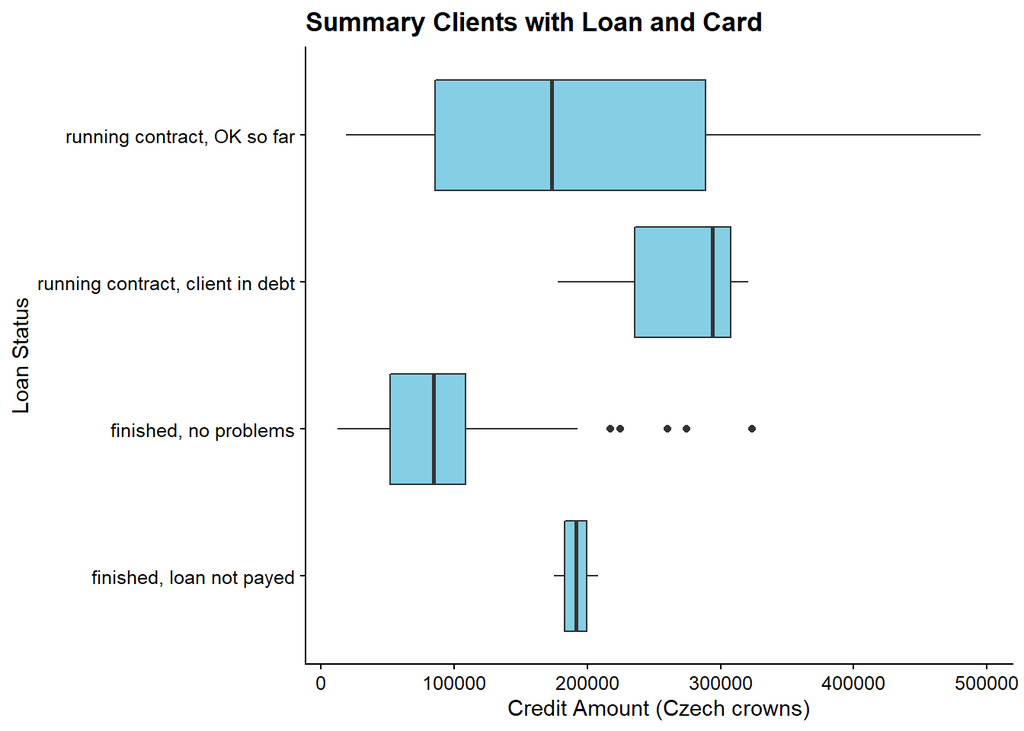

```r
p <- ggplot(loan_card_details_dataset, aes(x = loan_status, y = loan_amount))
p +
  geom_boxplot(fill = "#85CFE6") +
  labs(x = "Loan Status", y = "Credit Amount (Czech crowns)", title = "Summary Clients with Loan and Card") +
  coord_flip()
```

## Order details

In addition to cards and loans we want to look at the standing orders that our clients have set.

```sql
SELECT DISTINCT
  account.account_id,
  orders.orders_id,
  orders.amount,
  CASE
    WHEN k_symbol = 'POJISTNE' THEN 'insurance payment'
    WHEN k_symbol = 'SIPO' THEN 'household'
    WHEN k_symbol = 'LEASING' THEN 'leasing'
    WHEN k_symbol = 'UVER' THEN 'loan payment'
    ELSE 'other'
  END as payment_category,
        CASE
          WHEN
            (
              CASE
                WHEN MOD(client.birth_number / 100, 100) > 50 THEN (981231-(client.birth_number-5000))/10000
                ELSE (981231-client.birth_number)/10000
              END <= 25) THEN '<25'
          WHEN
            (
              CASE
                WHEN MOD(client.birth_number / 100, 100) > 50 THEN (981231-(client.birth_number-5000))/10000
                ELSE (981231-client.birth_number)/10000
              END <= 35) THEN '26-35'
          WHEN
            (
              CASE
                WHEN MOD(client.birth_number / 100, 100) > 50 THEN (981231-(client.birth_number-5000))/10000
                ELSE (981231-client.birth_number)/10000
              END <= 45) THEN '36-45'
          WHEN
            (
              CASE
                WHEN MOD(client.birth_number / 100, 100) > 50 THEN (981231-(client.birth_number-5000))/10000
                ELSE (981231-client.birth_number)/10000
              END <= 55) THEN '46-55'
          WHEN
            (
              CASE
                WHEN MOD(client.birth_number / 100, 100) > 50 THEN (981231-(client.birth_number-5000))/10000
                ELSE (981231-client.birth_number)/10000
              END <= 65) THEN '56-65'
        ELSE '65+'
        END as age_group
FROM orders
JOIN account ON orders.account_id=account.account_id
JOIN disp ON account.account_id=disp.account_id
JOIN client ON disp.client_id=client.client_id
WHERE disp.type = 'OWNER'
GROUP BY account.account_id, orders.orders_id, age_group
```

```r
head(orders_details_dataset)
```

| account_id | orders_id | amount | payment_category | age_group |
| --- | --- | --- | --- | --- |
| 1 | 29401 | 2452 | household | 26-35 |
| 2 | 29402 | 3373 | loan payment | 46-55 |
| 2 | 29403 | 7266 | household | 46-55 |
| 3 | 29404 | 1135 | household | 36-45 |
| 3 | 29405 | 327 | other | 36-45 |
| 3 | 29406 | 3539 | insurance payment | 36-45 |

We want to know how many owners have standing orders.

```sql
SELECT
  COUNT(DISTINCT account.account_id) as total_accounts,
  COUNT(DISTINCT orders.account_id) as accounts_with_orders
FROM account
LEFT JOIN orders ON orders.account_id = account.account_id
```

```r
pct_accounts_with_orders <-  count_accounts %>%
  mutate(freq = accounts_with_orders / sum(total_accounts), pct = round((freq*100), 0))
pct_accounts_with_orders
```

| total_accounts | accounts_with_orders | freq | pct |
| --- | --- | --- | --- |
| 4500 | 3758 | 0.8351111 | 84 |

And how the different orders categories are distributed.

```sql
SELECT
  CASE
    WHEN k_symbol = 'POJISTNE' THEN 'insurance payment'
    WHEN k_symbol = 'SIPO' THEN 'household'
    WHEN k_symbol = 'LEASING' THEN 'leasing'
    WHEN k_symbol = 'UVER' THEN 'loan payment'
    ELSE 'other'
  END as payment_category,
COUNT(*)
FROM orders
GROUP BY
  CASE
    WHEN k_symbol = 'POJISTNE' THEN 'insurance payment'
    WHEN k_symbol = 'SIPO' THEN 'household'
    WHEN k_symbol = 'LEASING' THEN 'leasing'
    WHEN k_symbol = 'UVER' THEN 'loan payment'
    ELSE 'other'
  END
```

```r
head(count_orders_category)
```

| payment_category | count |
| --- | --- |
| insurance payment | 532 |
| loan payment | 717 |
| household | 3502 |
| leasing | 341 |
| other | 1379 |

```r
sum(count_orders_category$count)
```

```
## [1] 6471
```

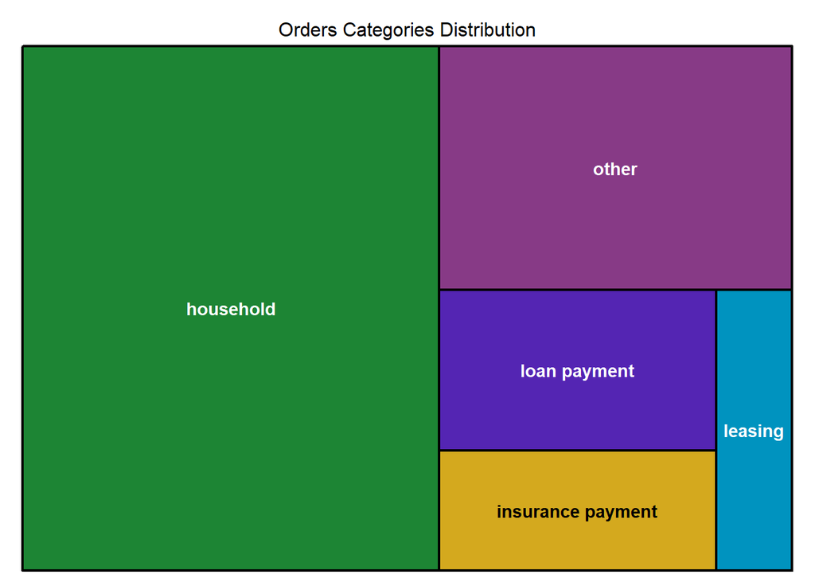

```r
count_orders_category %>%
  treemap(
        index="payment_category",
        vSize="count",
        palette=qua_scale_seven,
        title="Orders Categories Distribution",
        fontsize.title=12
        )
```

The plot show us crystal clear that the most common standing orders are the ones put aside for household issues (3502). Most likely this amount is devoted to pay mortgages.

How does the order picture look like per age group?

```sql
SELECT DISTINCT
  CASE
    WHEN k_symbol = 'POJISTNE' THEN 'insurance payment'
    WHEN k_symbol = 'SIPO' THEN 'household'
    WHEN k_symbol = 'LEASING' THEN 'leasing'
    WHEN k_symbol = 'UVER' THEN 'loan payment'
    ELSE 'other'
  END as payment_category,
        CASE
          WHEN
            (
              CASE
                WHEN MOD(client.birth_number / 100, 100) > 50 THEN (981231-(client.birth_number-5000))/10000
                ELSE (981231-client.birth_number)/10000
              END <= 25) THEN '<25'
          WHEN
            (
              CASE
                WHEN MOD(client.birth_number / 100, 100) > 50 THEN (981231-(client.birth_number-5000))/10000
                ELSE (981231-client.birth_number)/10000
              END <= 35) THEN '26-35'
          WHEN
            (
              CASE
                WHEN MOD(client.birth_number / 100, 100) > 50 THEN (981231-(client.birth_number-5000))/10000
                ELSE (981231-client.birth_number)/10000
              END <= 45) THEN '36-45'
          WHEN
            (
              CASE
                WHEN MOD(client.birth_number / 100, 100) > 50 THEN (981231-(client.birth_number-5000))/10000
                ELSE (981231-client.birth_number)/10000
              END <= 55) THEN '46-55'
          WHEN
            (
              CASE
                WHEN MOD(client.birth_number / 100, 100) > 50 THEN (981231-(client.birth_number-5000))/10000
                ELSE (981231-client.birth_number)/10000
              END <= 65) THEN '56-65'
        ELSE '65+'
        END as age_group,
COUNT(*)
FROM orders
JOIN account ON orders.account_id=account.account_id
JOIN disp ON account.account_id=disp.account_id
JOIN client ON disp.client_id=client.client_id
WHERE disp.type = 'OWNER'
GROUP BY
  CASE
    WHEN k_symbol = 'POJISTNE' THEN 'insurance payment'
    WHEN k_symbol = 'SIPO' THEN 'household'
    WHEN k_symbol = 'LEASING' THEN 'leasing'
    WHEN k_symbol = 'UVER' THEN 'loan payment'
    ELSE 'other'
  END,
        CASE
          WHEN
            (
              CASE
                WHEN MOD(client.birth_number / 100, 100) > 50 THEN (981231-(client.birth_number-5000))/10000
                ELSE (981231-client.birth_number)/10000
              END <= 25) THEN '<25'
          WHEN
            (
              CASE
                WHEN MOD(client.birth_number / 100, 100) > 50 THEN (981231-(client.birth_number-5000))/10000
                ELSE (981231-client.birth_number)/10000
              END <= 35) THEN '26-35'
          WHEN
            (
              CASE
                WHEN MOD(client.birth_number / 100, 100) > 50 THEN (981231-(client.birth_number-5000))/10000
                ELSE (981231-client.birth_number)/10000
              END <= 45) THEN '36-45'
          WHEN
            (
              CASE
                WHEN MOD(client.birth_number / 100, 100) > 50 THEN (981231-(client.birth_number-5000))/10000
                ELSE (981231-client.birth_number)/10000
              END <= 55) THEN '46-55'
          WHEN
            (
              CASE
                WHEN MOD(client.birth_number / 100, 100) > 50 THEN (981231-(client.birth_number-5000))/10000
                ELSE (981231-client.birth_number)/10000
              END <= 65) THEN '56-65'
        ELSE '65+'
  END
```

```r
head(count_orders_accounts_age_group)
```

| payment_category | age_group | count |
| --- | --- | --- |
| household | <25 | 449 |
| household | 26-35 | 603 |
| household | 36-45 | 591 |
| household | 46-55 | 610 |
| household | 56-65 | 548 |
| household | 65+ | 701 |

```r
sum(count_orders_accounts_age_group$count)
```

```
## [1] 6471
```

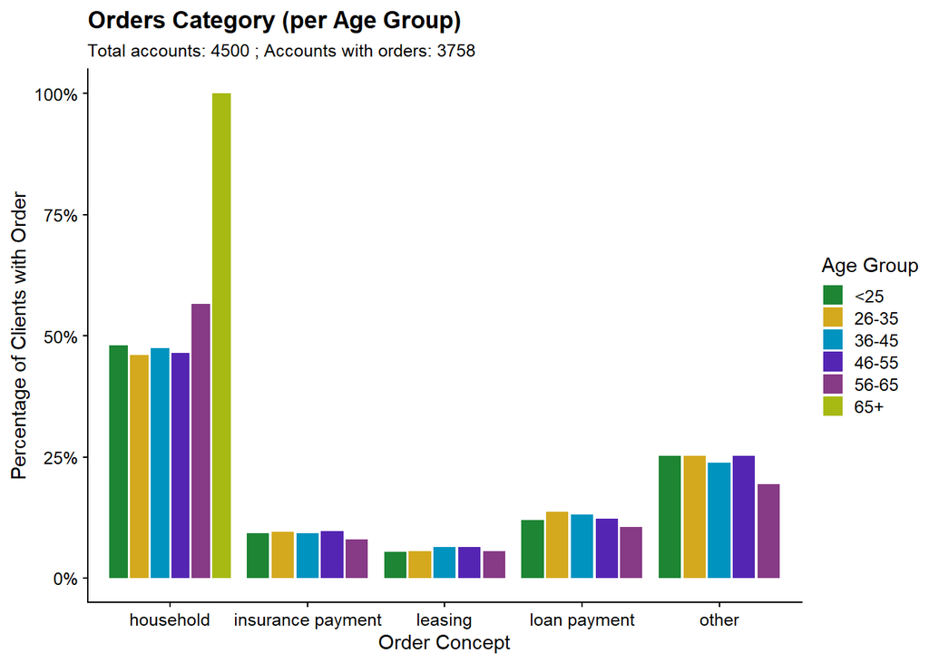

```r
p <- ggplot(orders_details_dataset, aes(x = payment_category, fill = age_group))
p +
  geom_bar(position = "dodge2", aes(y = ..prop.., group = age_group)) +
  scale_y_continuous(labels = scales::percent_format(accuracy = TRUE, scale = 100)) +
  labs(x = "Order Concept", y = "Percentage of Clients with Order", fill='', title = "Orders Category (per Age Group)", subtitle = paste("Total accounts:", pct_accounts_with_orders$total_accounts, ";", "Accounts with orders:", pct_accounts_with_orders$accounts_with_orders)) +
  theme(legend.position = "right") +
  scale_fill_manual(name = "Age Group", values = qua_scale_seven)
```

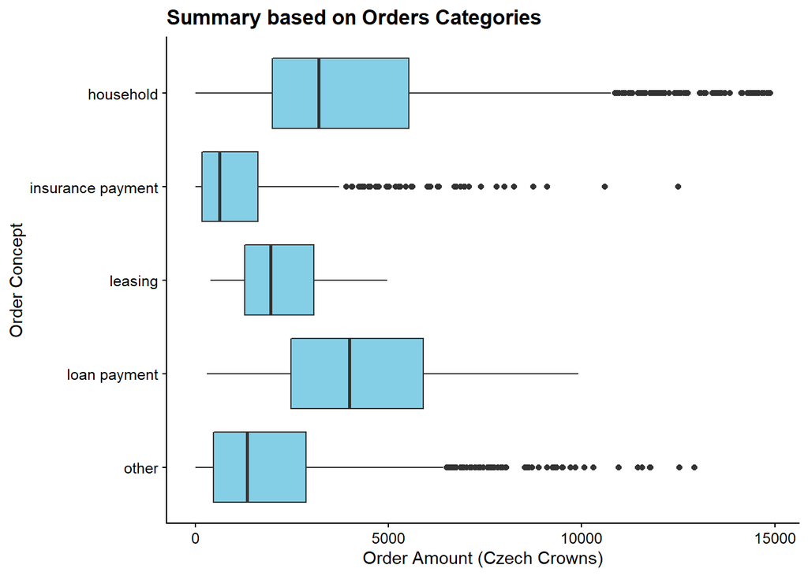

```r
p <- ggplot(orders_details_dataset, aes(x = reorder(payment_category, desc(payment_category)), y = amount))
p +
  geom_boxplot(fill = "#85CFE6") +
  labs(x = "Order Concept", y = "Order Amount (Czech Crowns)", title = "Summary based on Orders Categories") +
  coord_flip()
```

## Balance details

One of the main criteria to accomplish profitable cross-selling banking is looking at the asset of our clients. We want to know what is the total recorded balance of every client in our available data (date: 1998-12-31).

```sql
SELECT
   account_id,
   date,
   balance
FROM trans
WHERE
   (
      trans_id
   )
   IN
   (
      SELECT
         MAX(trans_id) as last_id
      FROM
         trans
      GROUP BY account_id
   )
ORDER BY account_id
```

Next, we are looking at the range of our balance distribution to set up properly our grouped bins.

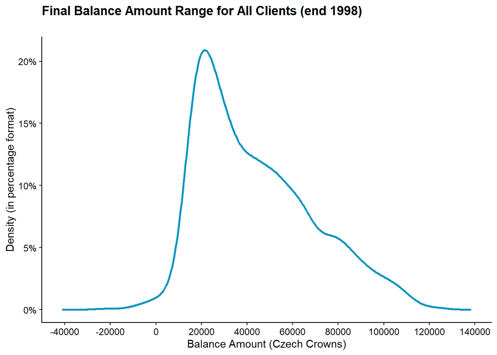

```r
p <- ggplot(balance, aes(x = balance))
p +
  geom_line(stat = "density", lwd = 1, color = "#0093BF") +
  scale_x_continuous(breaks = seq(-40000, 200000, 20000)) +
  scale_y_continuous(labels = scales::percent_format(accuracy = TRUE, scale = 1000000)) +
  # theme(legend.position = "right", ) +
  scale_color_manual(values = "#0093BF") +
  labs(y = "Density (in percentage format)", x = "Balance Amount (Czech Crowns)", title = "Final Balance Amount Range for All Clients (end 1998)", subtitle = "")
```

Once we have the final balance as off end 1998 (last date available), we want to use the information related to demographics characteristics of our client to categorize them by age and gender, and group them by balance.

```sql
SELECT
   trans.account_id,
   trans.date,
   trans.balance,
   disp.type as owner_type,
    CASE
      WHEN (MOD(client.birth_number / 100, 100) > 50) THEN 'female'
      ELSE 'male'
    END as "gender",
    CASE
      WHEN MOD(client.birth_number / 100, 100) > 50 THEN (981231-(client.birth_number-5000))/10000
      ELSE (981231-client.birth_number)/10000
     END as "age",
        CASE
          WHEN
            (
              CASE
                WHEN MOD(client.birth_number / 100, 100) > 50 THEN (981231-(client.birth_number-5000))/10000
                ELSE (981231-client.birth_number)/10000
              END <= 25) THEN '<25'
          WHEN
            (
              CASE
                WHEN MOD(client.birth_number / 100, 100) > 50 THEN (981231-(client.birth_number-5000))/10000
                ELSE (981231-client.birth_number)/10000
              END <= 35) THEN '26-35'
          WHEN
            (
              CASE
                WHEN MOD(client.birth_number / 100, 100) > 50 THEN (981231-(client.birth_number-5000))/10000
                ELSE (981231-client.birth_number)/10000
              END <= 45) THEN '36-45'
          WHEN
            (
              CASE
                WHEN MOD(client.birth_number / 100, 100) > 50 THEN (981231-(client.birth_number-5000))/10000
                ELSE (981231-client.birth_number)/10000
              END <= 55) THEN '46-55'
          WHEN
            (
              CASE
                WHEN MOD(client.birth_number / 100, 100) > 50 THEN (981231-(client.birth_number-5000))/10000
                ELSE (981231-client.birth_number)/10000
              END <= 65) THEN '56-65'
        ELSE '65+'
        END as age_group,
    CASE
      WHEN (balance <=0) THEN '<0'
      WHEN (balance >0 AND balance < 10000) THEN '<10k'
      WHEN (balance >=10000 AND balance <20000) THEN '10k-20k'
      WHEN (balance >=20000 AND balance <40000) THEN '20k-40k'
      WHEN (balance >=40000 AND balance <60000) THEN '40k-60k'
      WHEN (balance >=60000 AND balance <80000) THEN '60k-80k'
      WHEN (balance >=80000 AND balance <100000) THEN '80k-100k'
      WHEN (balance >=10000) THEN 'more 100k'
    END as balance_category,
    CASE
      WHEN trans.k_symbol ='POJISTNE' THEN 'payment insurance'
      WHEN trans.k_symbol ='SLUZBY' THEN 'payment statement'
      WHEN trans.k_symbol ='UROK' THEN 'credit interest'
      WHEN trans.k_symbol ='SANKC. UROK' THEN 'neg interest action'
      WHEN trans.k_symbol ='SIPO' THEN 'household'
      WHEN trans.k_symbol ='DUCHOD' THEN 'old-age pension'
      WHEN trans.k_symbol ='UVER' THEN 'payment loan'
    ELSE 'NA'
    END as spend_category
FROM trans
JOIN account ON trans.account_id = account.account_id
JOIN disp ON account.account_id = disp.account_id
JOIN client ON disp.client_id = client.client_id
WHERE
   (
      trans_id
   )
   IN
   (
      SELECT
         MAX(trans_id) as last_id
      FROM
         trans
      GROUP BY account_id
   )
   AND disp.type = 'OWNER'
ORDER BY account_id
```

```r
head(balance_dataset)
```

| account_id | date | balance | owner_type | gender | age | age_group | balance_category | spend_category |
| --- | --- | --- | --- | --- | --- | --- | --- | --- |
| 1 | 1998-12-31 | 13466.5 | OWNER | female | 28 | 26-35 | 10k-20k | credit interest |
| 2 | 1998-12-31 | 42628.1 | OWNER | male | 53 | 46-55 | 40k-60k | credit interest |
| 3 | 1998-12-31 | 51096.1 | OWNER | male | 42 | 36-45 | 40k-60k | credit interest |
| 4 | 1998-12-31 | 33720.7 | OWNER | male | 79 | 65+ | 20k-40k | credit interest |
| 5 | 1998-12-31 | 28088.3 | OWNER | male | 69 | 65+ | 20k-40k | credit interest |
| 6 | 1998-12-31 | 47668.0 | OWNER | female | 60 | 56-65 | 40k-60k | credit interest |

Let´s see what the final balance tell us about our clients.

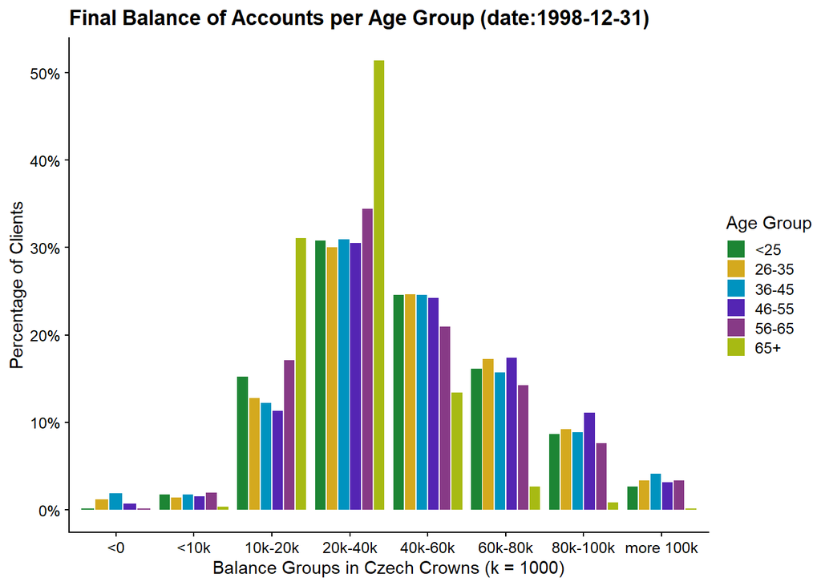

```r
p <- ggplot(balance_dataset, aes(x = reorder(balance_category, balance), fill = age_group))
p +
  geom_bar(position = "dodge2", aes(y = ..prop.., group = age_group)) +
  scale_y_continuous(labels = scales::percent_format(accuracy = TRUE, scale = 100)) +
  labs(x = "Balance Groups in Czech Crowns (k = 1000)", y = "Percentage of Clients", fill='', title = "Final Balance of Accounts per Age Group (date:1998-12-31)") +
  scale_fill_manual(name = "Age Group", values = qua_scale_seven)
```

```r
balance_age_group_summarized <- balance_dataset %>%
  group_by(balance_category) %>%
  summarize(N = n()) %>%
  mutate(freq = N / sum(N), pct = round((freq*100), 0))
balance_age_group_summarized
```

| balance_category | N | freq | pct |
| --- | --- | --- | --- |
| <0 | 33 | 0.0073333 | 1 |
| <10k | 68 | 0.0151111 | 2 |
| 10k-20k | 716 | 0.1591111 | 16 |
| 20k-40k | 1525 | 0.3388889 | 34 |
| 40k-60k | 1014 | 0.2253333 | 23 |
| 60k-80k | 650 | 0.1444444 | 14 |
| 80k-100k | 363 | 0.0806667 | 8 |
| more 100k | 131 | 0.0291111 | 3 |

Looking at the plot, we can see that the balance range of most clients (62%) is located between 10k and 50k. There is also a significant second cluster of customers (33%) that is located on top of the majority (50k-100k). The portion of clients “in the red” (1%) is not relevant.

### Balance details card

Create an aggregate median function in SQL to use it to see balance development over the time.

With the aid of the timeframe analysis, we can better understand the behaviour of our customers regarding to the products involved in our cross-selling project. Here we are looking at the card development in a twelve months interval (before and after card adquisition).

```sql
SELECT
  new_client.age_group,
  CASE
    WHEN date_trunc('month', trans.date) = date_trunc('month', card.issued) THEN '+0'
    WHEN date_trunc('month', trans.date) = date_trunc('month', card.issued) - interval '1 month' THEN '-1'
    WHEN date_trunc('month', trans.date) = date_trunc('month', card.issued) - interval '2 month' THEN '-2'
    WHEN date_trunc('month', trans.date) = date_trunc('month', card.issued) - interval '3 month' THEN '-3'
    WHEN date_trunc('month', trans.date) = date_trunc('month', card.issued) - interval '4 month' THEN '-4'
    WHEN date_trunc('month', trans.date) = date_trunc('month', card.issued) - interval '5 month' THEN '-5'
    WHEN date_trunc('month', trans.date) = date_trunc('month', card.issued) - interval '6 month' THEN '-6'
    WHEN date_trunc('month', trans.date) = date_trunc('month', card.issued) - interval '7 month' THEN '-7'
    WHEN date_trunc('month', trans.date) = date_trunc('month', card.issued) - interval '8 month' THEN '-8'
    WHEN date_trunc('month', trans.date) = date_trunc('month', card.issued) - interval '9 month' THEN '-9'
    WHEN date_trunc('month', trans.date) = date_trunc('month', card.issued) - interval '10 month' THEN '-10'
    WHEN date_trunc('month', trans.date) = date_trunc('month', card.issued) - interval '11 month' THEN '-11'
    WHEN date_trunc('month', trans.date) = date_trunc('month', card.issued) - interval '12 month' THEN '-12'
    WHEN date_trunc('month', trans.date) = date_trunc('month', card.issued) + interval '1 month' THEN '+1'
    WHEN date_trunc('month', trans.date) = date_trunc('month', card.issued) + interval '2 month' THEN '+2'
    WHEN date_trunc('month', trans.date) = date_trunc('month', card.issued) + interval '3 month' THEN '+3'
    WHEN date_trunc('month', trans.date) = date_trunc('month', card.issued) + interval '4 month' THEN '+4'
    WHEN date_trunc('month', trans.date) = date_trunc('month', card.issued) + interval '5 month' THEN '+5'
    WHEN date_trunc('month', trans.date) = date_trunc('month', card.issued) + interval '6 month' THEN '+6'
    WHEN date_trunc('month', trans.date) = date_trunc('month', card.issued) + interval '7 month' THEN '+7'
    WHEN date_trunc('month', trans.date) = date_trunc('month', card.issued) + interval '8 month' THEN '+8'
    WHEN date_trunc('month', trans.date) = date_trunc('month', card.issued) + interval '9 month' THEN '+9'
    WHEN date_trunc('month', trans.date) = date_trunc('month', card.issued) + interval '10 month' THEN '+10'
    WHEN date_trunc('month', trans.date) = date_trunc('month', card.issued) + interval '11 month' THEN '+11'
    ELSE '+12'
  END as month_interval,
  avg(trans.balance) as avg_balance,
  fmv_median(trans.balance) as median_balance
FROM
  (
    SELECT client.client_id,
      CASE
        WHEN (MOD(client.birth_number / 100, 100) > 50) THEN 'female'
        ELSE 'male'
      END as gender,
        CASE
          WHEN
            (
              CASE
                WHEN MOD(client.birth_number / 100, 100) > 50 THEN (981231-(client.birth_number-5000))/10000
                ELSE (981231-client.birth_number)/10000
              END <= 25) THEN '<25'
          WHEN
            (
              CASE
                WHEN MOD(client.birth_number / 100, 100) > 50 THEN (981231-(client.birth_number-5000))/10000
                ELSE (981231-client.birth_number)/10000
              END <= 35) THEN '26-35'
          WHEN
            (
              CASE
                WHEN MOD(client.birth_number / 100, 100) > 50 THEN (981231-(client.birth_number-5000))/10000
                ELSE (981231-client.birth_number)/10000
              END <= 45) THEN '36-45'
          WHEN
            (
              CASE
                WHEN MOD(client.birth_number / 100, 100) > 50 THEN (981231-(client.birth_number-5000))/10000
                ELSE (981231-client.birth_number)/10000
              END <= 55) THEN '46-55'
          WHEN
            (
              CASE
                WHEN MOD(client.birth_number / 100, 100) > 50 THEN (981231-(client.birth_number-5000))/10000
                ELSE (981231-client.birth_number)/10000
              END <= 65) THEN '56-65'
        ELSE '65+'
        END as age_group,
      client.district_id
FROM client) new_client
JOIN disp ON new_client.client_id = disp.client_id
JOIN card ON disp.disp_id = card.disp_id
JOIN account ON account.account_id = disp.account_id
JOIN trans ON trans.account_id = account.account_id
WHERE date_trunc('month', trans.date) >=date_trunc('month', card.issued) - interval '12 month'
  AND date_trunc('month', trans.date) <=date_trunc('month', card.issued) + interval '12 month'
GROUP BY new_client.age_group,
  CASE
    WHEN date_trunc('month', trans.date) = date_trunc('month', card.issued) THEN '+0'
    WHEN date_trunc('month', trans.date) = date_trunc('month', card.issued) - interval '1 month' THEN '-1'
    WHEN date_trunc('month', trans.date) = date_trunc('month', card.issued) - interval '2 month' THEN '-2'
    WHEN date_trunc('month', trans.date) = date_trunc('month', card.issued) - interval '3 month' THEN '-3'
    WHEN date_trunc('month', trans.date) = date_trunc('month', card.issued) - interval '4 month' THEN '-4'
    WHEN date_trunc('month', trans.date) = date_trunc('month', card.issued) - interval '5 month' THEN '-5'
    WHEN date_trunc('month', trans.date) = date_trunc('month', card.issued) - interval '6 month' THEN '-6'
    WHEN date_trunc('month', trans.date) = date_trunc('month', card.issued) - interval '7 month' THEN '-7'
    WHEN date_trunc('month', trans.date) = date_trunc('month', card.issued) - interval '8 month' THEN '-8'
    WHEN date_trunc('month', trans.date) = date_trunc('month', card.issued) - interval '9 month' THEN '-9'
    WHEN date_trunc('month', trans.date) = date_trunc('month', card.issued) - interval '10 month' THEN '-10'
    WHEN date_trunc('month', trans.date) = date_trunc('month', card.issued) - interval '11 month' THEN '-11'
    WHEN date_trunc('month', trans.date) = date_trunc('month', card.issued) - interval '12 month' THEN '-12'
    WHEN date_trunc('month', trans.date) = date_trunc('month', card.issued) + interval '1 month' THEN '+1'
    WHEN date_trunc('month', trans.date) = date_trunc('month', card.issued) + interval '2 month' THEN '+2'
    WHEN date_trunc('month', trans.date) = date_trunc('month', card.issued) + interval '3 month' THEN '+3'
    WHEN date_trunc('month', trans.date) = date_trunc('month', card.issued) + interval '4 month' THEN '+4'
    WHEN date_trunc('month', trans.date) = date_trunc('month', card.issued) + interval '5 month' THEN '+5'
    WHEN date_trunc('month', trans.date) = date_trunc('month', card.issued) + interval '6 month' THEN '+6'
    WHEN date_trunc('month', trans.date) = date_trunc('month', card.issued) + interval '7 month' THEN '+7'
    WHEN date_trunc('month', trans.date) = date_trunc('month', card.issued) + interval '8 month' THEN '+8'
    WHEN date_trunc('month', trans.date) = date_trunc('month', card.issued) + interval '9 month' THEN '+9'
    WHEN date_trunc('month', trans.date) = date_trunc('month', card.issued) + interval '10 month' THEN '+10'
    WHEN date_trunc('month', trans.date) = date_trunc('month', card.issued) + interval '11 month' THEN '+11'
    ELSE '+12'
  END
ORDER BY 1,2
```

```r
head(balance_interval_card)
```

| age_group | month_interval | avg_balance | median_balance |
| --- | --- | --- | --- |
| <25 | +0 | 52443.29 | 49719.90 |
| <25 | -1 | 53875.29 | 51185.10 |
| <25 | +1 | 53341.96 | 49981.60 |
| <25 | -10 | 47907.71 | 43363.95 |
| <25 | +10 | 53608.76 | 51397.45 |
| <25 | -11 | 45622.68 | 42070.60 |

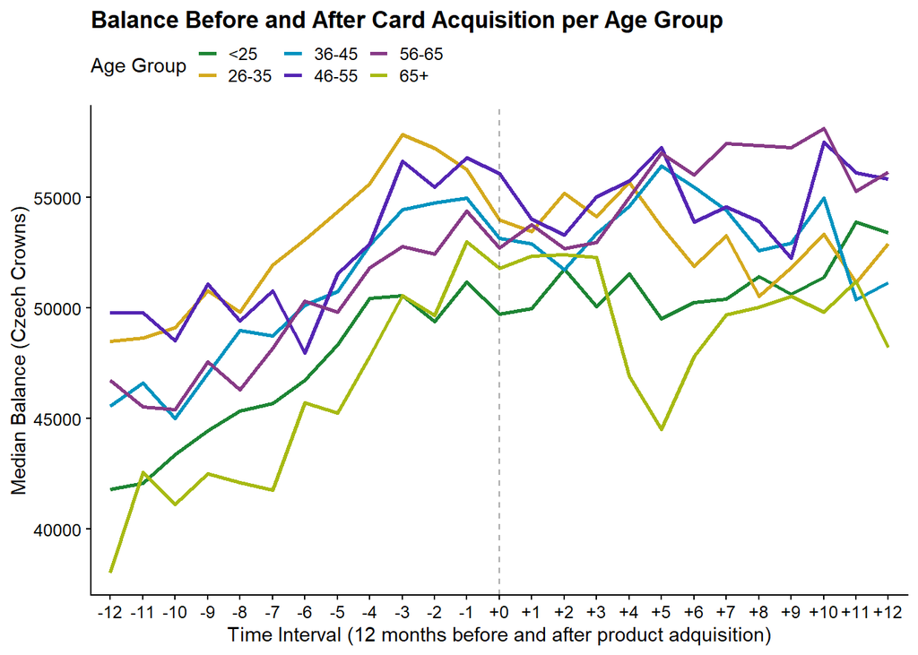

```r
# Reorder factors levels to make clearer time development
level_order <- factor(balance_interval_card$month_interval, levels = c('-12', '-11', '-10','-9', '-8', '-7','-6', '-5', '-4','-3', '-2', '-1', '+0', '+1', '+2', '+3', '+4', '+5', '+6', '+7', '+8', '+9', '+10', '+11', '+12'))

# Plot time development
p <- ggplot(balance_interval_card, aes(x = level_order, y = median_balance, group = age_group, color = age_group))
p +
  geom_line(lwd = 1) +
  labs(x = "Time Interval (12 months before and after product adquisition)" , y = "Median Balance (Czech Crowns)", fill='', title = "Balance Before and After Card Acquisition per Age Group") +
  theme(legend.position = "top") +
  geom_vline(xintercept = 13, alpha = 0.5, colour = "grey30", linetype = "dashed") +
  scale_color_manual(name ="Age Group", values = qua_scale_seven)
```

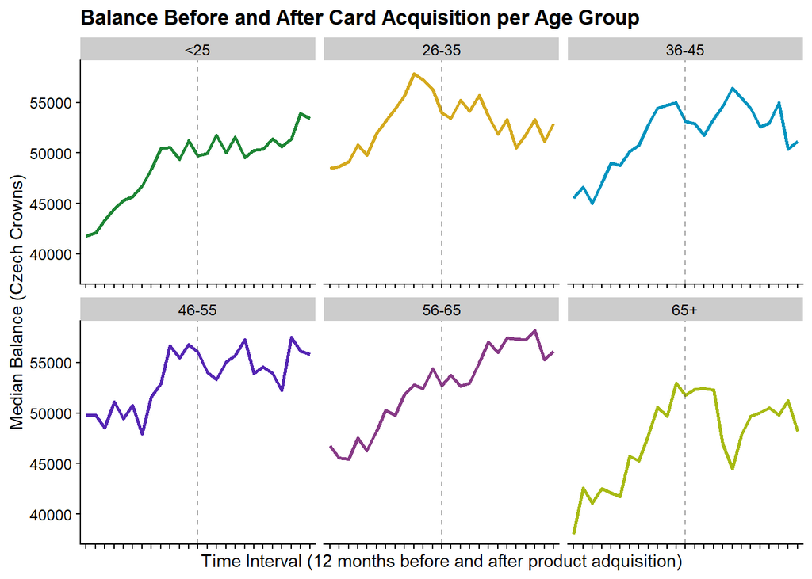

```r
# Reorder factors levels to make clearer time development
level_order <- factor(balance_interval_card$month_interval, levels = c('-12', '-11', '-10','-9', '-8', '-7','-6', '-5', '-4','-3', '-2', '-1', '+0', '+1', '+2', '+3', '+4', '+5', '+6', '+7', '+8', '+9', '+10', '+11', '+12'))

# Plot time development
p <- ggplot(balance_interval_card, aes(x = level_order, y = median_balance, group = age_group, color = age_group))
p +
  geom_line(lwd = 1) +
  labs(x = "Time Interval (12 months before and after product adquisition)" , y = "Median Balance (Czech Crowns)", fill='', title = "Balance Before and After Card Acquisition per Age Group") +
  facet_wrap(~ age_group, scales = "free_x") +
  theme(legend.position = "none", axis.text.x = element_blank()) +
  geom_vline(xintercept = 13, alpha = .5, colour = "grey30", linetype = "dashed") +
  scale_color_manual(values = qua_scale_seven)
```

### Balance details loan

Now we want to do the same for our other main product: loans.

```sql
SELECT new_client.age_group,
  CASE
    WHEN date_trunc('month', trans.date) = date_trunc('month', loan.date) THEN '+0'
    WHEN date_trunc('month', trans.date) = date_trunc('month', loan.date) - interval '1 month' THEN '-1'
    WHEN date_trunc('month', trans.date) = date_trunc('month', loan.date) - interval '2 month' THEN '-2'
    WHEN date_trunc('month', trans.date) = date_trunc('month', loan.date) - interval '3 month' THEN '-3'
    WHEN date_trunc('month', trans.date) = date_trunc('month', loan.date) - interval '4 month' THEN '-4'
    WHEN date_trunc('month', trans.date) = date_trunc('month', loan.date) - interval '5 month' THEN '-5'
    WHEN date_trunc('month', trans.date) = date_trunc('month', loan.date) - interval '6 month' THEN '-6'
    WHEN date_trunc('month', trans.date) = date_trunc('month', loan.date) - interval '7 month' THEN '-7'
    WHEN date_trunc('month', trans.date) = date_trunc('month', loan.date) - interval '8 month' THEN '-8'
    WHEN date_trunc('month', trans.date) = date_trunc('month', loan.date) - interval '9 month' THEN '-9'
    WHEN date_trunc('month', trans.date) = date_trunc('month', loan.date) - interval '10 month' THEN '-10'
    WHEN date_trunc('month', trans.date) = date_trunc('month', loan.date) - interval '11 month' THEN '-11'
    WHEN date_trunc('month', trans.date) = date_trunc('month', loan.date) - interval '12 month' THEN '-12'
    WHEN date_trunc('month', trans.date) = date_trunc('month', loan.date) + interval '1 month' THEN '+1'
    WHEN date_trunc('month', trans.date) = date_trunc('month', loan.date) + interval '2 month' THEN '+2'
    WHEN date_trunc('month', trans.date) = date_trunc('month', loan.date) + interval '3 month' THEN '+3'
    WHEN date_trunc('month', trans.date) = date_trunc('month', loan.date) + interval '4 month' THEN '+4'
    WHEN date_trunc('month', trans.date) = date_trunc('month', loan.date) + interval '5 month' THEN '+5'
    WHEN date_trunc('month', trans.date) = date_trunc('month', loan.date) + interval '6 month' THEN '+6'
    WHEN date_trunc('month', trans.date) = date_trunc('month', loan.date) + interval '7 month' THEN '+7'
    WHEN date_trunc('month', trans.date) = date_trunc('month', loan.date) + interval '8 month' THEN '+8'
    WHEN date_trunc('month', trans.date) = date_trunc('month', loan.date) + interval '9 month' THEN '+9'
    WHEN date_trunc('month', trans.date) = date_trunc('month', loan.date) + interval '10 month' THEN '+10'
    WHEN date_trunc('month', trans.date) = date_trunc('month', loan.date) + interval '11 month' THEN '+11'
    ELSE '+12'
  END as month_interval,
  avg(trans.balance) as avg_balance,
  median(trans.balance) as median_balance
FROM
  (
    SELECT client.client_id,
      CASE
        WHEN (MOD(client.birth_number / 100, 100) > 50) THEN 'female'
        ELSE 'male'
      END as gender,
        CASE
          WHEN
            (
              CASE
                WHEN MOD(client.birth_number / 100, 100) > 50 THEN (981231-(client.birth_number-5000))/10000
                ELSE (981231-client.birth_number)/10000
              END <= 25) THEN '<25'
          WHEN
            (
              CASE
                WHEN MOD(client.birth_number / 100, 100) > 50 THEN (981231-(client.birth_number-5000))/10000
                ELSE (981231-client.birth_number)/10000
              END <= 35) THEN '26-35'
          WHEN
            (
              CASE
                WHEN MOD(client.birth_number / 100, 100) > 50 THEN (981231-(client.birth_number-5000))/10000
                ELSE (981231-client.birth_number)/10000
              END <= 45) THEN '36-45'
          WHEN
            (
              CASE
                WHEN MOD(client.birth_number / 100, 100) > 50 THEN (981231-(client.birth_number-5000))/10000

                ELSE (981231-client.birth_number)/10000
              END <= 55) THEN '46-55'
        ELSE '55+'
        END as age_group,
      client.district_id
FROM client) new_client
JOIN disp ON new_client.client_id = disp.client_id
JOIN account ON account.account_id = disp.account_id
JOIN trans ON trans.account_id = account.account_id
JOIN loan ON loan.account_id = account.account_id
WHERE date_trunc('month', trans.date) >=date_trunc('month', loan.date) - interval '12 month'
  AND date_trunc('month', trans.date) <=date_trunc('month', loan.date) + interval '12 month'
  AND disp.type = 'OWNER'
GROUP BY new_client.age_group,
  CASE
    WHEN date_trunc('month', trans.date) = date_trunc('month', loan.date) THEN '+0'
    WHEN date_trunc('month', trans.date) = date_trunc('month', loan.date) - interval '1 month' THEN '-1'
    WHEN date_trunc('month', trans.date) = date_trunc('month', loan.date) - interval '2 month' THEN '-2'
    WHEN date_trunc('month', trans.date) = date_trunc('month', loan.date) - interval '3 month' THEN '-3'
    WHEN date_trunc('month', trans.date) = date_trunc('month', loan.date) - interval '4 month' THEN '-4'
    WHEN date_trunc('month', trans.date) = date_trunc('month', loan.date) - interval '5 month' THEN '-5'
    WHEN date_trunc('month', trans.date) = date_trunc('month', loan.date) - interval '6 month' THEN '-6'
    WHEN date_trunc('month', trans.date) = date_trunc('month', loan.date) - interval '7 month' THEN '-7'
    WHEN date_trunc('month', trans.date) = date_trunc('month', loan.date) - interval '8 month' THEN '-8'
    WHEN date_trunc('month', trans.date) = date_trunc('month', loan.date) - interval '9 month' THEN '-9'
    WHEN date_trunc('month', trans.date) = date_trunc('month', loan.date) - interval '10 month' THEN '-10'
    WHEN date_trunc('month', trans.date) = date_trunc('month', loan.date) - interval '11 month' THEN '-11'
    WHEN date_trunc('month', trans.date) = date_trunc('month', loan.date) - interval '12 month' THEN '-12'
    WHEN date_trunc('month', trans.date) = date_trunc('month', loan.date) + interval '1 month' THEN '+1'
    WHEN date_trunc('month', trans.date) = date_trunc('month', loan.date) + interval '2 month' THEN '+2'
    WHEN date_trunc('month', trans.date) = date_trunc('month', loan.date) + interval '3 month' THEN '+3'
    WHEN date_trunc('month', trans.date) = date_trunc('month', loan.date) + interval '4 month' THEN '+4'
    WHEN date_trunc('month', trans.date) = date_trunc('month', loan.date) + interval '5 month' THEN '+5'
    WHEN date_trunc('month', trans.date) = date_trunc('month', loan.date) + interval '6 month' THEN '+6'
    WHEN date_trunc('month', trans.date) = date_trunc('month', loan.date) + interval '7 month' THEN '+7'
    WHEN date_trunc('month', trans.date) = date_trunc('month', loan.date) + interval '8 month' THEN '+8'
    WHEN date_trunc('month', trans.date) = date_trunc('month', loan.date) + interval '9 month' THEN '+9'
    WHEN date_trunc('month', trans.date) = date_trunc('month', loan.date) + interval '10 month' THEN '+10'
    WHEN date_trunc('month', trans.date) = date_trunc('month', loan.date) + interval '11 month' THEN '+11'
    ELSE '+12'
  END
ORDER BY 1,2
```

```r
head(balance_interval_loan)
```

| age_group | month_interval | avg_balance | median_balance |
| --- | --- | --- | --- |
| <25 | +0 | 46910.58 | 43750.7 |
| <25 | -1 | 43639.00 | 41127.9 |
| <25 | +1 | 47539.83 | 42492.5 |
| <25 | -10 | 43429.15 | 38409.4 |
| <25 | +10 | 43624.15 | 39962.9 |
| <25 | -11 | 45813.78 | 42363.5 |

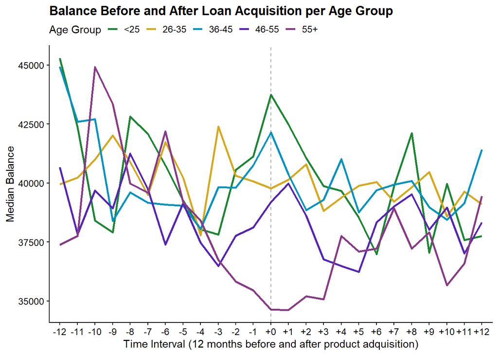

```r
level_order <- factor(balance_interval_loan$month_interval, levels = c('-12', '-11', '-10','-9', '-8', '-7','-6', '-5', '-4','-3', '-2', '-1', '+0', '+1', '+2', '+3', '+4', '+5', '+6', '+7', '+8', '+9', '+10', '+11', '+12'))

p <- ggplot(balance_interval_loan, aes(x = level_order, y = median_balance, group = age_group, color = age_group))
p +
  geom_line(lwd = 1) +
  #scale_color_manual(values=c("#67000d", "#a50f15", "#ef3b2c", "#fcbba1")) +
  labs(x = "Time Interval (12 months before and after product adquisition)", y = "Median Balance", fill='', title = "Balance Before and After Loan Acquisition per Age Group") +
  theme(legend.position = "top") +
  geom_vline(xintercept = 13, alpha = 0.5, colour = "grey30", linetype = "dashed") +
  scale_color_manual(name ="Age Group", values = qua_scale_seven)
```

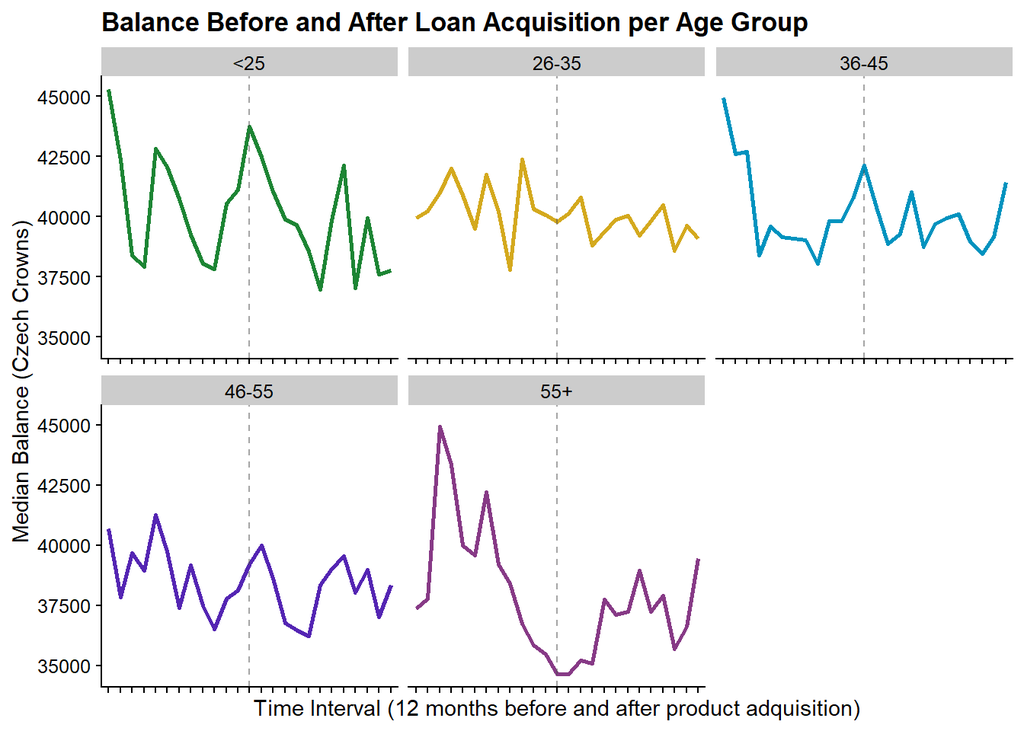

```r
level_order <- factor(balance_interval_loan$month_interval, levels = c('-12', '-11', '-10','-9', '-8', '-7','-6', '-5', '-4','-3', '-2', '-1', '+0', '+1', '+2', '+3', '+4', '+5', '+6', '+7', '+8', '+9', '+10', '+11', '+12'))

p <- ggplot(balance_interval_loan, aes(x = level_order, y = median_balance, group = age_group, color = age_group))
p +
  geom_line(lwd = 1) +
  labs(x = "Time Interval (12 months before and after product adquisition)", y = "Median Balance (Czech Crowns)", fill='', title = "Balance Before and After Loan Acquisition per Age Group") +
  theme(legend.position = "top", axis.text.x = element_blank()) +
  geom_vline(xintercept = 13, alpha = 0.5, colour = "grey30", linetype = "dashed") +
  facet_wrap(~ age_group, scales = "free_x") +
  scale_color_manual(values = qua_scale_seven) +
  theme(legend.position = "none")
```

# 5 Hypotheses

Regarding the first product that we are focusing on our Cross-Selling Analysis, credit **cards**, we can see that most clients that can own a credit card (4500 owner clients) don’t have one (3608). Among the clients who don´t have a credit card yet, clients aged between 25 and 75 are the largest age group. That gives us a good opportunity to develop strategies to make credit cards more appealing to this group. Gender seems not to be significant regarding credit card acquisition: women and men are pretty much equally distributed.

We can get some additional details from the card issuing timeline. We can see that many of our customers wait at least 20 months until they either request a card for the first time or the bank offers them one. That could be due to bank policies which are too restrictive and make it difficult for the client to acquire a credit card or to long waiting time periods. We could facilitate credit cards to our customers from the beginning of our business relation, making it easier for them to get this product as soon as possible.

As for the running contracts which are in debt, the median balance is the highest. This fact shows us that there is still room for improvement in our risk evaluation mechanisms to minimize loss.

The timeline since a customer opened an account and got a loan shows a mean and median of about 12 months. Most clients wait to request a loan between 8 and 18 months. We saw that in general, our clients are good “payers”, so we could offer them, after a rigorous risk evaluation, the possibility of a loan right after they open an account.

When we combine both our products – cards and loans – we noticed that just 170 out of our 4500 owner clients have/had both of services: cards and loans. This suggests a great potential for our cross-selling campaign. For those customers having only one of the two products, we should offer them the missing one.

The largest group of clients with a credit card and a running loan contract is the group between 25 and 50 years old. An upgrade with better conditions in one or all the owned products could fulfill two goals: a stronger long-term relationship and an indirect advertisement campaign that attract new customers.

Standing **orders** represent another bank service largely used by the customers. An analysis of this service allows us to explore new possibilities to build or keep a long-term relationship with our customers. Our data shows that almost every account has at least one order related to it (3758 out of 4500) and that the most common standing orders (3502) are the ones related to household topics. By analyzing the orders distribution, the summary statistics and the age group of the most common users, we can infer that a large portion of these payments is devoted to pay mortgages. The median amount of this type of standing orders is relatively high, which is also a hint that, among other things, we are dealing with mortgages. We could encourage our customers to extend that service to other billing payments promoting our e-banking service for instance.

To understand the behavior of our clients regarding our products, we must look back in the past. **Balance** over time for clients with credit cards shows that the median balance among the different age groups varies significantly. While for our youngest group (<25) and the people between 46-65 years old, the median balance remains the same during few months and even increases as the time goes, young adults between 26-45 see how their account balance shrinks a little.

Noteworthy it is that the median balance for customer with cards who are over 65 years sinks dramatically around four months after card purchase. As additional service, we could offer them more support and advice right after the purchase to help them manage this product properly.

When we turn our attention to the development of balance in relation with loans, the first thing we notice is that it is difficult to see the big picture. Before our customers decide to request a loan, the median balance normally fluctuates a lot. As expected, the median balance for all our customers - except for oldest ones that own this kind of product - decreases after a loan purchase. We may want to focus our efforts to offer this product an the early stages of our business relation when the balance of our clients is at the highest point.

# 6 Next Steps

SQL queries needed to consolidate one dataset with relevant information about one sample client.

Query 1 out of 4

```sql
SELECT
    account.account_id,
    new_client.client_id,
    new_client.gender,
    new_client.age,
    new_client.age_group,
    disp.type,
    trans.balance as last_balance,
    CASE COUNT(card.card_id)
        WHEN 0 then 'N'
        ELSE 'Y'
    END as has_cards,
    ROUND(CAST((card.issued - account.date) as decimal) / 30)  as cards_lapse_time_months

FROM
  (
    SELECT client.client_id,
    CASE
      WHEN (MOD(client.birth_number / 100, 100) > 50) THEN 'female'
      ELSE 'male'
    END as "gender",
    CASE
      WHEN MOD(client.birth_number / 100, 100) > 50 THEN (981231-(client.birth_number-5000))/10000
      ELSE (981231-client.birth_number)/10000
     END as "age",
        CASE
          WHEN
            (
              CASE
                WHEN MOD(client.birth_number / 100, 100) > 50 THEN (981231-(client.birth_number-5000))/10000
                ELSE (981231-client.birth_number)/10000
              END <= 25) THEN '<25'
          WHEN
            (
              CASE
                WHEN MOD(client.birth_number / 100, 100) > 50 THEN (981231-(client.birth_number-5000))/10000
                ELSE (981231-client.birth_number)/10000
              END <= 35) THEN '26-35'
          WHEN
            (
              CASE
                WHEN MOD(client.birth_number / 100, 100) > 50 THEN (981231-(client.birth_number-5000))/10000
                ELSE (981231-client.birth_number)/10000
              END <= 45) THEN '36-45'
          WHEN
            (
              CASE
                WHEN MOD(client.birth_number / 100, 100) > 50 THEN (981231-(client.birth_number-5000))/10000
                ELSE (981231-client.birth_number)/10000
              END <= 55) THEN '46-55'
          WHEN
            (
              CASE
                WHEN MOD(client.birth_number / 100, 100) > 50 THEN (981231-(client.birth_number-5000))/10000
                ELSE (981231-client.birth_number)/10000
              END <= 65) THEN '56-65'
        ELSE '65+'
        END as age_group,
      client.district_id
FROM client) new_client
JOIN disp ON new_client.client_id = disp.client_id
LEFT JOIN card ON disp.disp_id = card.disp_id
LEFT JOIN account ON disp.account_id = account.account_id
JOIN trans ON trans.account_id = account.account_id
WHERE
   (
      trans_id
   )
   IN
   (
      SELECT
         MAX(trans_id) as last_id
      FROM
         trans
      GROUP BY account_id
   )
   AND disp.type = 'OWNER'
   AND new_client.client_id = 76
GROUP BY
account.account_id,
new_client.client_id,
new_client.gender,
new_client.age_group,
new_client.age,
disp.type,
trans.balance,
ROUND(CAST((card.issued - account.date) as decimal) / 30)
ORDER BY new_client.client_id
```

```r
print(consol_client_dataset_01)
```

```
##   account_id client_id gender age age_group  type last_balance has_cards
## 1         65        76 female  31     26-35 OWNER      56145.9         Y
##   cards_lapse_time_months
## 1                      12
```

Query 2 out of 4

```sql
SELECT
    account.account_id,
    new_client.client_id,
    new_client.gender,
    new_client.age,
    new_client.age_group,
    disp.type,
    ROUND(CAST((card.issued - account.date) as decimal) / 30)  as cards_lapse_time_months,
CASE
    WHEN date_trunc('month', trans.date) = date_trunc('month', card.issued) THEN '+0'
    WHEN date_trunc('month', trans.date) = date_trunc('month', card.issued) - interval '1 month' THEN '-1'
    WHEN date_trunc('month', trans.date) = date_trunc('month', card.issued) - interval '2 month' THEN '-2'
    WHEN date_trunc('month', trans.date) = date_trunc('month', card.issued) - interval '3 month' THEN '-3'
    WHEN date_trunc('month', trans.date) = date_trunc('month', card.issued) - interval '4 month' THEN '-4'
    WHEN date_trunc('month', trans.date) = date_trunc('month', card.issued) - interval '5 month' THEN '-5'
    WHEN date_trunc('month', trans.date) = date_trunc('month', card.issued) - interval '6 month' THEN '-6'
    WHEN date_trunc('month', trans.date) = date_trunc('month', card.issued) - interval '7 month' THEN '-7'
    WHEN date_trunc('month', trans.date) = date_trunc('month', card.issued) - interval '8 month' THEN '-8'
    WHEN date_trunc('month', trans.date) = date_trunc('month', card.issued) - interval '9 month' THEN '-9'
    WHEN date_trunc('month', trans.date) = date_trunc('month', card.issued) - interval '10 month' THEN '-10'
    WHEN date_trunc('month', trans.date) = date_trunc('month', card.issued) - interval '11 month' THEN '-11'
    WHEN date_trunc('month', trans.date) = date_trunc('month', card.issued) - interval '12 month' THEN '-12'
    WHEN date_trunc('month', trans.date) = date_trunc('month', card.issued) + interval '1 month' THEN '+1'
    WHEN date_trunc('month', trans.date) = date_trunc('month', card.issued) + interval '2 month' THEN '+2'
    WHEN date_trunc('month', trans.date) = date_trunc('month', card.issued) + interval '3 month' THEN '+3'
    WHEN date_trunc('month', trans.date) = date_trunc('month', card.issued) + interval '4 month' THEN '+4'
    WHEN date_trunc('month', trans.date) = date_trunc('month', card.issued) + interval '5 month' THEN '+5'
    WHEN date_trunc('month', trans.date) = date_trunc('month', card.issued) + interval '6 month' THEN '+6'
    WHEN date_trunc('month', trans.date) = date_trunc('month', card.issued) + interval '7 month' THEN '+7'
    WHEN date_trunc('month', trans.date) = date_trunc('month', card.issued) + interval '8 month' THEN '+8'
    WHEN date_trunc('month', trans.date) = date_trunc('month', card.issued) + interval '9 month' THEN '+9'
    WHEN date_trunc('month', trans.date) = date_trunc('month', card.issued) + interval '10 month' THEN '+10'
    WHEN date_trunc('month', trans.date) = date_trunc('month', card.issued) + interval '11 month' THEN '+11'
    ELSE '+12'
  END as month_interval,
  avg(trans.balance) as avg_balance
FROM
  (
    SELECT client.client_id,
    CASE
      WHEN (MOD(client.birth_number / 100, 100) > 50) THEN 'female'
      ELSE 'male'
    END as "gender",
    CASE
      WHEN MOD(client.birth_number / 100, 100) > 50 THEN (981231-(client.birth_number-5000))/10000
      ELSE (981231-client.birth_number)/10000
     END as "age",
        CASE
          WHEN
            (
              CASE
                WHEN MOD(client.birth_number / 100, 100) > 50 THEN (981231-(client.birth_number-5000))/10000
                ELSE (981231-client.birth_number)/10000
              END <= 25) THEN '<25'
          WHEN
            (
              CASE
                WHEN MOD(client.birth_number / 100, 100) > 50 THEN (981231-(client.birth_number-5000))/10000
                ELSE (981231-client.birth_number)/10000
              END <= 35) THEN '26-35'
          WHEN
            (
              CASE
                WHEN MOD(client.birth_number / 100, 100) > 50 THEN (981231-(client.birth_number-5000))/10000
                ELSE (981231-client.birth_number)/10000
              END <= 45) THEN '36-45'
          WHEN
            (
              CASE
                WHEN MOD(client.birth_number / 100, 100) > 50 THEN (981231-(client.birth_number-5000))/10000
                ELSE (981231-client.birth_number)/10000
              END <= 55) THEN '46-55'
          WHEN
            (
              CASE
                WHEN MOD(client.birth_number / 100, 100) > 50 THEN (981231-(client.birth_number-5000))/10000
                ELSE (981231-client.birth_number)/10000
              END <= 65) THEN '56-65'
        ELSE '65+'
        END as age_group,
      client.district_id
FROM client) new_client
JOIN disp ON new_client.client_id = disp.client_id
JOIN card ON disp.disp_id = card.disp_id
JOIN account ON disp.account_id = account.account_id
JOIN trans ON trans.account_id = account.account_id
WHERE disp.type = 'OWNER'
AND new_client.client_id = 76
GROUP BY
    account.account_id,
    new_client.client_id,
    new_client.gender,
    new_client.age,
    new_client.age_group,
    disp.type,
    ROUND(CAST((card.issued - account.date) as decimal) / 30),
  CASE
    WHEN date_trunc('month', trans.date) = date_trunc('month', card.issued) THEN '+0'
    WHEN date_trunc('month', trans.date) = date_trunc('month', card.issued) - interval '1 month' THEN '-1'
    WHEN date_trunc('month', trans.date) = date_trunc('month', card.issued) - interval '2 month' THEN '-2'
    WHEN date_trunc('month', trans.date) = date_trunc('month', card.issued) - interval '3 month' THEN '-3'
    WHEN date_trunc('month', trans.date) = date_trunc('month', card.issued) - interval '4 month' THEN '-4'
    WHEN date_trunc('month', trans.date) = date_trunc('month', card.issued) - interval '5 month' THEN '-5'
    WHEN date_trunc('month', trans.date) = date_trunc('month', card.issued) - interval '6 month' THEN '-6'
    WHEN date_trunc('month', trans.date) = date_trunc('month', card.issued) - interval '7 month' THEN '-7'
    WHEN date_trunc('month', trans.date) = date_trunc('month', card.issued) - interval '8 month' THEN '-8'
    WHEN date_trunc('month', trans.date) = date_trunc('month', card.issued) - interval '9 month' THEN '-9'
    WHEN date_trunc('month', trans.date) = date_trunc('month', card.issued) - interval '10 month' THEN '-10'
    WHEN date_trunc('month', trans.date) = date_trunc('month', card.issued) - interval '11 month' THEN '-11'
    WHEN date_trunc('month', trans.date) = date_trunc('month', card.issued) - interval '12 month' THEN '-12'
    WHEN date_trunc('month', trans.date) = date_trunc('month', card.issued) + interval '1 month' THEN '+1'
    WHEN date_trunc('month', trans.date) = date_trunc('month', card.issued) + interval '2 month' THEN '+2'
    WHEN date_trunc('month', trans.date) = date_trunc('month', card.issued) + interval '3 month' THEN '+3'
    WHEN date_trunc('month', trans.date) = date_trunc('month', card.issued) + interval '4 month' THEN '+4'
    WHEN date_trunc('month', trans.date) = date_trunc('month', card.issued) + interval '5 month' THEN '+5'
    WHEN date_trunc('month', trans.date) = date_trunc('month', card.issued) + interval '6 month' THEN '+6'
    WHEN date_trunc('month', trans.date) = date_trunc('month', card.issued) + interval '7 month' THEN '+7'
    WHEN date_trunc('month', trans.date) = date_trunc('month', card.issued) + interval '8 month' THEN '+8'
    WHEN date_trunc('month', trans.date) = date_trunc('month', card.issued) + interval '9 month' THEN '+9'
    WHEN date_trunc('month', trans.date) = date_trunc('month', card.issued) + interval '10 month' THEN '+10'
    WHEN date_trunc('month', trans.date) = date_trunc('month', card.issued) + interval '11 month' THEN '+11'
    ELSE '+12'
    END
ORDER BY new_client.client_id
```

```r
print(consol_client_dataset_02)
```

```
##    account_id client_id gender age age_group  type cards_lapse_time_months
## 1          65        76 female  31     26-35 OWNER                      12
## 2          65        76 female  31     26-35 OWNER                      12
## 3          65        76 female  31     26-35 OWNER                      12
## 4          65        76 female  31     26-35 OWNER                      12
## 5          65        76 female  31     26-35 OWNER                      12
## 6          65        76 female  31     26-35 OWNER                      12
## 7          65        76 female  31     26-35 OWNER                      12
## 8          65        76 female  31     26-35 OWNER                      12
## 9          65        76 female  31     26-35 OWNER                      12
## 10         65        76 female  31     26-35 OWNER                      12
## 11         65        76 female  31     26-35 OWNER                      12
## 12         65        76 female  31     26-35 OWNER                      12
## 13         65        76 female  31     26-35 OWNER                      12
## 14         65        76 female  31     26-35 OWNER                      12
```

[output cut: 37 more lines]

```r
consol_client_dataset_02 <- consol_client_dataset_02 %>%
  spread(key = month_interval, avg_balance) # Tidy our dataset in more suitable way
print(consol_client_dataset_02)
```

```
##   account_id client_id gender age age_group  type cards_lapse_time_months
## 1         65        76 female  31     26-35 OWNER                      12
##        -1      -10     -11 -12       -2       -3       -4       -5       -6
## 1 51207.5 49756.33 24860.1 600 55050.77 59032.93 65946.47 57482.74 60580.03
##         -7       -8      -9       +0       +1      +10      +11      +12
## 1 64462.14 60636.47 56750.8 48390.21 46589.95 49248.28 48981.78 60577.27
##         +2       +3       +4       +5       +6       +7       +8    +9
## 1 53698.24 48705.75 50766.37 52373.24 49107.55 46634.53 58181.39 51954
```

Query 3 out of 4

```sql
SELECT
    account.account_id,
    new_client.client_id,
    new_client.gender,
    new_client.age,
    new_client.age_group,
    disp.type,
    loan.amount,
    trans.balance as last_balance,
    CASE COUNT(loan.loan_id)
        WHEN 0 then 'N'
        ELSE 'Y'
    END as has_loans,
    ROUND(CAST((loan.date - account.date) as decimal) / 30)  as loans_lapse_time_months,
  CASE
    WHEN status ='A' THEN 'finished, no problems'
    WHEN status ='B' THEN 'finished, loan not payed'
    WHEN status ='C' THEN 'running contract, OK so far'
    WHEN status ='D' THEN 'running contract, client in debt'
    END as "loan_status"
FROM
  (
    SELECT client.client_id,
    CASE
      WHEN (MOD(client.birth_number / 100, 100) > 50) THEN 'female'
      ELSE 'male'
    END as "gender",
    CASE
      WHEN MOD(client.birth_number / 100, 100) > 50 THEN (981231-(client.birth_number-5000))/10000
      ELSE (981231-client.birth_number)/10000
     END as "age",
        CASE
          WHEN
            (
              CASE
                WHEN MOD(client.birth_number / 100, 100) > 50 THEN (981231-(client.birth_number-5000))/10000
                ELSE (981231-client.birth_number)/10000
              END <= 25) THEN '<25'
          WHEN
            (
              CASE
                WHEN MOD(client.birth_number / 100, 100) > 50 THEN (981231-(client.birth_number-5000))/10000
                ELSE (981231-client.birth_number)/10000
              END <= 35) THEN '26-35'
          WHEN
            (
              CASE
                WHEN MOD(client.birth_number / 100, 100) > 50 THEN (981231-(client.birth_number-5000))/10000
                ELSE (981231-client.birth_number)/10000
              END <= 45) THEN '36-45'
          WHEN
            (
              CASE
                WHEN MOD(client.birth_number / 100, 100) > 50 THEN (981231-(client.birth_number-5000))/10000
                ELSE (981231-client.birth_number)/10000
              END <= 55) THEN '46-55'
          WHEN
            (
              CASE
                WHEN MOD(client.birth_number / 100, 100) > 50 THEN (981231-(client.birth_number-5000))/10000
                ELSE (981231-client.birth_number)/10000
              END <= 65) THEN '56-65'
        ELSE '65+'
        END as age_group,
      client.district_id
FROM client) new_client
JOIN disp ON new_client.client_id = disp.client_id
LEFT JOIN card ON disp.disp_id = card.disp_id
LEFT JOIN account ON disp.account_id = account.account_id
JOIN trans ON trans.account_id = account.account_id
LEFT JOIN loan ON loan.account_id = account.account_id
WHERE
   (
      trans_id
   )
   IN
   (
      SELECT
         MAX(trans_id) as last_id
      FROM
         trans
      GROUP BY account_id
   )
   AND disp.type = 'OWNER'
   AND new_client.client_id = 76
GROUP BY
account.account_id,
new_client.client_id,
new_client.gender,
new_client.age_group,
new_client.age,
disp.type,
loan.amount,
loan.status,
trans.balance,
ROUND(CAST((loan.date - account.date) as decimal) / 30)
ORDER BY new_client.client_id
```

```r
print(consol_client_dataset_03)
```

```
##   account_id client_id gender age age_group  type amount last_balance has_loans
## 1         65        76 female  31     26-35 OWNER     NA      56145.9         N
##   loans_lapse_time_months loan_status
## 1                      NA        <NA>
```

Query 4 out of 4

```sql
SELECT DISTINCT
  account.account_id,
  client.client_id,
  orders.amount as orders_amount,
  CASE
    WHEN k_symbol = 'POJISTNE' THEN 'insurance payment'
    WHEN k_symbol = 'SIPO' THEN 'household'
    WHEN k_symbol = 'LEASING' THEN 'leasing'
    WHEN k_symbol = 'UVER' THEN 'loan payment'
    ELSE 'other'
  END as payment_category,
    CASE COUNT(orders.orders_id)
    WHEN 0 then 'N'
    ELSE 'Y'
    END as has_orders
FROM orders
JOIN account ON orders.account_id=account.account_id
JOIN disp ON account.account_id=disp.account_id
JOIN client ON disp.client_id=client.client_id
WHERE disp.type = 'OWNER'
AND client.client_id = 76
GROUP BY account.account_id, orders.orders_id, client.client_id
ORDER BY account_id
```

```r
print(consol_client_dataset_04)
```

```
##   account_id client_id orders_amount  payment_category has_orders
## 1         65        76           686         household          Y
## 2         65        76          3315             other          Y
## 3         65        76          3401 insurance payment          Y
```

```r
consol_client_dataset_04 <- consol_client_dataset_04 %>%
  spread(key = payment_category, orders_amount) # Tidy our dataset in more suitable way
consol_client_dataset_04
```

| account_id | client_id | has_orders | household | insurance payment | other |
| --- | --- | --- | --- | --- | --- |
| 65 | 76 | Y | 686 | 3401 | 3315 |

A unique dataset is created in R with all relevant data.

```r
# First join
join_01 <- consol_client_dataset_01 %>%
  left_join(consol_client_dataset_02, by = "client_id")

# Second join
join_02 <- join_01 %>%
  left_join(consol_client_dataset_03, by = "client_id")
join_02
```

| account_id.x | client_id | gender.x | age.x | age_group.x | type.x | last_balance.x | has_cards | cards_lapse_time_months.x | account_id.y | gender.y | age.y | age_group.y | type.y | cards_lapse_time_months.y | -1 | -10 | -11 | -12 | -2 | -3 | -4 | -5 | -6 | -7 | -8 | -9 | +0 | +1 | +10 | … |
| --- | --- | --- | --- | --- | --- | --- | --- | --- | --- | --- | --- | --- | --- | --- | --- | --- | --- | --- | --- | --- | --- | --- | --- | --- | --- | --- | --- | --- | --- | --- |
| 65 | 76 | female | 31 | 26-35 | OWNER | 56145.9 | Y | 12 | 65 | female | 31 | 26-35 | OWNER | 12 | 51207.5 | 49756.33 | 24860.1 | 600 | 55050.77 | 59032.93 | 65946.47 | 57482.74 | 60580.03 | 64462.14 | 60636.47 | 56750.8 | 48390.21 | 46589.95 | 49248.28 | … |

```r
# Third join
join_03 <- join_02 %>%
  left_join(consol_client_dataset_04, by = "client_id") %>%
    select(c(
      account_id.x,
      client_id,
      gender.x,
      age.x,
      age_group.x,
      type.x,
      last_balance.y,
      has_cards,
      cards_lapse_time_months.x,
      "-12",
      "-11",
      "-10",
      "-9",
      "-8",
      "-7",
      "-6",
      "-5",
      "-4",
      "-3",
      "-2",
      "-1",
      "+0",
      "+1",
      "+2",
      "+3",
      "+4",
      "+5",
      "+6",
      "+7",
      "+8",
      "+9",
      "+10",
      "+11",
      "+12",
      "has_loans",
      "household",
      "insurance payment",
      "other",
      has_orders
    ))
```

```r
# Rename columns
colnames(join_03)
```

```
##  [1] "account_id.x"              "client_id"
##  [3] "gender.x"                  "age.x"
##  [5] "age_group.x"               "type.x"
##  [7] "last_balance.y"            "has_cards"
##  [9] "cards_lapse_time_months.x" "-12"
## [11] "-11"                       "-10"
## [13] "-9"                        "-8"
## [15] "-7"                        "-6"
## [17] "-5"                        "-4"
## [19] "-3"                        "-2"
## [21] "-1"                        "+0"
## [23] "+1"                        "+2"
## [25] "+3"                        "+4"
## [27] "+5"                        "+6"
## [29] "+7"                        "+8"
## [31] "+9"                        "+10"
## [33] "+11"                       "+12"
## [35] "has_loans"                 "household"
## [37] "insurance payment"         "other"
## [39] "has_orders"
```

```r
new_col_names <- c(
  "account_id",
  "client_id",
  "gender",
  "age",
  "age_group",
  "client_type",
  "last_balance",
  "has_cards",
  "cards_lapse_time_months",
  "avg_balance_month_interval (-12)",
  "avg_balance_month_interval (-11)",
  "avg_balance_month_interval (-10)",
  "avg_balance_month_interval (-9)",
  "avg_balance_month_interval (-8)",
  "avg_balance_month_interval (-7)",
  "avg_balance_month_interval (-6)",
  "avg_balance_month_interval (-5)",
  "avg_balance_month_interval (-4)",
  "avg_balance_month_interval (-3)",
  "avg_balance_month_interval (-2)",
  "avg_balance_month_interval (-1)",
  "avg_balance_month_interval (+0)",
  "avg_balance_month_interval (+1)",
  "avg_balance_month_interval (+2)",
  "avg_balance_month_interval (+3)",
  "avg_balance_month_interval (+4)",
  "avg_balance_month_interval (+5)",
  "avg_balance_month_interval (+6)",
  "avg_balance_month_interval (+7)",
  "avg_balance_month_interval (+8)",
  "avg_balance_month_interval (+9)",
  "avg_balance_month_interval (+10)",
  "avg_balance_month_interval (+11)",
  "avg_balance_month_interval (+12)",
  "has_loans",
  "amount_order_household",
  "amount_order_insurance_payment",
  "amount_order_other",
  "has_orders"
)
colnames(join_03) <- new_col_names
join_03
```

| account_id | client_id | gender | age | age_group | client_type | last_balance | has_cards | cards_lapse_time_months | avg_balance_month_interval (-12) | avg_balance_month_interval (-11) | avg_balance_month_interval (-10) | avg_balance_month_interval (-9) | avg_balance_month_interval (-8) | avg_balance_month_interval (-7) | avg_balance_month_interval (-6) | avg_balance_month_interval (-5) | avg_balance_month_interval (-4) | avg_balance_month_interval (-3) | avg_balance_month_interval (-2) | avg_balance_month_interval (-1) | avg_balance_month_interval (+0) | avg_balance_month_interval (+1) | avg_balance_month_interval (+2) | avg_balance_month_interval (+3) | avg_balance_month_interval (+4) | avg_balance_month_interval (+5) | avg_balance_month_interval (+6) | avg_balance_month_interval (+7) | avg_balance_month_interval (+8) | … |
| --- | --- | --- | --- | --- | --- | --- | --- | --- | --- | --- | --- | --- | --- | --- | --- | --- | --- | --- | --- | --- | --- | --- | --- | --- | --- | --- | --- | --- | --- | --- |
| 65 | 76 | female | 31 | 26-35 | OWNER | 56145.9 | Y | 12 | 600 | 24860.1 | 49756.33 | 56750.8 | 60636.47 | 64462.14 | 60580.03 | 57482.74 | 65946.47 | 59032.93 | 55050.77 | 51207.5 | 48390.21 | 46589.95 | 53698.24 | 48705.75 | 50766.37 | 52373.24 | 49107.55 | 46634.53 | 58181.39 | … |

```r
# Rearrange columns
consol_dataset <- join_03[, c(
  "account_id",
  "client_id",
  "gender",
  "age",
  "age_group",
  "client_type",
  "last_balance",
  "has_cards",
  "cards_lapse_time_months",
  "avg_balance_month_interval (-12)",
  "avg_balance_month_interval (-11)",
  "avg_balance_month_interval (-10)",
  "avg_balance_month_interval (-9)",
  "avg_balance_month_interval (-8)",
  "avg_balance_month_interval (-7)",
  "avg_balance_month_interval (-6)",
  "avg_balance_month_interval (-5)",
  "avg_balance_month_interval (-4)",
  "avg_balance_month_interval (-3)",
  "avg_balance_month_interval (-2)",
  "avg_balance_month_interval (-1)",
  "avg_balance_month_interval (+0)",
  "avg_balance_month_interval (+1)",
  "avg_balance_month_interval (+2)",
  "avg_balance_month_interval (+3)",
  "avg_balance_month_interval (+4)",
  "avg_balance_month_interval (+5)",
  "avg_balance_month_interval (+6)",
  "avg_balance_month_interval (+7)",
  "avg_balance_month_interval (+8)",
  "avg_balance_month_interval (+9)",
  "avg_balance_month_interval (+10)",
  "avg_balance_month_interval (+11)",
  "avg_balance_month_interval (+12)",
  "has_loans",
  "has_orders",
  "amount_order_household",
  "amount_order_insurance_payment",
  "amount_order_other"
)]
consol_dataset
```

| account_id | client_id | gender | age | age_group | client_type | last_balance | has_cards | cards_lapse_time_months | avg_balance_month_interval (-12) | avg_balance_month_interval (-11) | avg_balance_month_interval (-10) | avg_balance_month_interval (-9) | avg_balance_month_interval (-8) | avg_balance_month_interval (-7) | avg_balance_month_interval (-6) | avg_balance_month_interval (-5) | avg_balance_month_interval (-4) | avg_balance_month_interval (-3) | avg_balance_month_interval (-2) | avg_balance_month_interval (-1) | avg_balance_month_interval (+0) | avg_balance_month_interval (+1) | avg_balance_month_interval (+2) | avg_balance_month_interval (+3) | avg_balance_month_interval (+4) | avg_balance_month_interval (+5) | avg_balance_month_interval (+6) | avg_balance_month_interval (+7) | avg_balance_month_interval (+8) | … |
| --- | --- | --- | --- | --- | --- | --- | --- | --- | --- | --- | --- | --- | --- | --- | --- | --- | --- | --- | --- | --- | --- | --- | --- | --- | --- | --- | --- | --- | --- | --- |
| 65 | 76 | female | 31 | 26-35 | OWNER | 56145.9 | Y | 12 | 600 | 24860.1 | 49756.33 | 56750.8 | 60636.47 | 64462.14 | 60580.03 | 57482.74 | 65946.47 | 59032.93 | 55050.77 | 51207.5 | 48390.21 | 46589.95 | 53698.24 | 48705.75 | 50766.37 | 52373.24 | 49107.55 | 46634.53 | 58181.39 | … |

And saved as a .Rdata file (output_data folder).

```r
save(consol_dataset, file = "output/sample_client_dataset.Rdata")
```

### Proposals

There is still much more information available in our data set to carry on further analysis. From the demographic data (relation **district**) we could classify a sample client even more. Attended to where he/she lives (region and city), geographical economic indicators like the average salary of the region/city and ratio of entrepreneurs and social statistics like unemployment and crime rate, we could draw up an accurate map of our customers that allow us to develop more effective business strategies.

Regarding to **trans** and **orders** datasets more useful insights could be extracted. We have already looked at the final balance and balance development from the trans relation. But this dataset includes rich information about, among others, kind, amount, date and recipient of a given transaction. This relation by himself or in combination with others like orders, could be a source of knowledge that help us to identify the target of our cross-selling project.

# 7 Linting

The code in this RMarkdown is linted with the [lintr package](https://github.com/jimhester/lintr), which is based on the [tidyverse style guide](http://style.tidyverse.org/).

```r
lintr::lint("main.Rmd", linters =
              lintr::with_defaults(
                commented_code_linter = NULL,
                trailing_whitespace_linter = NULL
                )
            )
# if you have additional scripts and want them to be linted too, add them here
# lintr::lint("scripts/my_script.R")
```